# Student Id : 2024AC05045

# Name : ARUNKUMAR K A

# Section : 2

# Machine Learning Assignment

# Problem Statement 6

## Objective

Software defect prediction is the process of identifying parts of the software, such as modules or instances that are likely to contain defects or bugs using predictive models. Software defect prediction is a crucial step in software engineering domain. The objective is to develop a mathematical model to classify the bugs using defect datasets.

## Dataset Information

- **Dataset**: defect_dataset-ant-1.3.xlsx (Apache Ant 1.3 project)
- **Metadata**: metadata_defectdataset.txt (detailed attribute descriptions)
- **Features**: 20 software metrics (wmc, dit, noc, cbo, rfc, lcom, ca, ce, npm, lcom3, loc, dam, moa, mfa, cam, ic, cbm, amc, max_cc, avg_cc)
- **Target**: bug (binary classification - defect or no defect)

# 1. Import Libraries/Dataset

## 1.b Import Required Libraries

We import all necessary libraries for data manipulation, visualization, machine learning, and evaluation.

```python
# 1.b Import Required Libraries

# Import essential libraries for data manipulation and analysis
import pandas as pd
import numpy as np
import matplotlib.pyplot as plt
import seaborn as sns
import warnings
warnings.filterwarnings('ignore')

# Machine Learning libraries
from sklearn.model_selection import train_test_split, cross_val_score, GridSearchCV, RandomizedSearchCV
from sklearn.preprocessing import StandardScaler, MinMaxScaler, RobustScaler
from sklearn.linear_model import LogisticRegression
from sklearn.tree import DecisionTreeClassifier
from sklearn.neighbors import KNeighborsClassifier
from sklearn.ensemble import RandomForestClassifier, GradientBoostingClassifier, VotingClassifier
from sklearn.metrics import accuracy_score, precision_score, recall_score, f1_score, roc_auc_score
from sklearn.metrics import classification_report, confusion_matrix, roc_curve, auc
from sklearn.feature_selection import SelectKBest, f_classif, RFE
from sklearn.tree import plot_tree

# Statistical libraries
from scipy import stats
from scipy.stats import skew, kurtosis

# Set random seed for reproducibility
np.random.seed(42)

# Configure plotting parameters
plt.style.use('ggplot')
sns.set_palette("husl")
plt.rcParams['figure.figsize'] = (12, 8)

print("1.b: Libraries imported successfully!")
print("Python version:", np.__version__)
print("Pandas version:", pd.__version__)
print("Scikit-learn imported successfully")
```

```
1.b: Libraries imported successfully!
Python version: 2.3.2
Pandas version: 2.3.1
Scikit-learn imported successfully
```

```python
# 1.a Download and Load the Dataset

# Load the dataset
try:
    # Load the Excel file containing defect dataset
    df = pd.read_excel('defect_dataset-ant-1.3.xlsx')
    print("1.a: Dataset loaded successfully!")
    print(f"Dataset shape: {df.shape}")
    print(f"Number of rows: {df.shape[0]}")
    print(f"Number of columns: {df.shape[1]}")

except FileNotFoundError:
    print("Error: Dataset file 'defect_dataset-ant-1.3.xlsx' not found in the current directory.")
    print("Please ensure the file is in the correct location.")
except Exception as e:
    print(f"Error loading dataset: {e}")

# Load metadata file for comprehensive understanding
try:
    with open('metadata_defectdataset.txt', 'r') as file:
        metadata_content = file.read()
    print("\n1.a: Metadata file loaded successfully!")
    print("First 200 characters of metadata:")
    print(metadata_content[:200] + "...")
except FileNotFoundError:
    print("Warning: Metadata file 'metadata_defectdataset.txt' not found.")

# Display basic information about the dataset
print("\n" + "="*50)
print("1.a: DATASET OVERVIEW")
print("="*50)
print(f"Dataset columns: {list(df.columns)}")
print(f"\nData types:\n{df.dtypes}")
print(f"\nBasic statistics:")
print(df.describe())
```

```
1.a: Dataset loaded successfully!
Dataset shape: (116, 24)
Number of rows: 116
Number of columns: 24

1.a: Metadata file loaded successfully!
First 200 characters of metadata:
Dataset

The dataset 'Defect Datasets' containing defect datasets gathered from real-world open source projects and has been widely used in previous studies for software defect prediction. Additionall...

==================================================
1.a: DATASET OVERVIEW
==================================================
Dataset columns: ['name', 'version', 'name.1', 'wmc', 'dit', 'noc', 'cbo', 'rfc', 'lcom', 'ca', 'ce', 'npm', 'lcom3', 'loc', 'dam', 'moa', 'mfa', 'cam', 'ic', 'cbm', 'amc', 'max_cc', 'avg_cc', 'bug']

Data types:
name        object
version    float64
name.1      object
wmc          int64
dit          int64
noc          int64
cbo          int64
rfc          int64
lcom         int64
ca           int64
ce           int64
npm          int64
lcom3      float64
loc          int64
dam        float64
moa          int64
mfa        float64
cam        float64
ic           int64
cbm          int64
amc        float64
max_cc       int64
avg_cc     float64
```

[output cut: 30 more lines]

```
50%      1.000000    0.000000    0.643966    0.450000    0.000000    0.000000
75%      1.000000    1.000000    0.880952    0.666667    1.000000    1.000000
max      1.000000    7.000000    1.000000    1.000000    4.000000    7.000000

              amc      max_cc      avg_cc         bug
count  116.000000  116.000000  116.000000  116.000000
mean    26.334244    4.025862    1.388611    0.094828
std     21.252732    4.709770    1.013539    0.294248
min      0.000000    0.000000    0.000000    0.000000
25%     11.988095    1.000000    0.809375    0.000000
50%     21.250000    2.000000    1.076300    0.000000
75%     33.512500    5.000000    1.578950    0.000000
max    101.000000   35.000000    5.869600    1.000000

[8 rows x 22 columns]
```

# 2. Data Visualization and Exploration [1M]

## 2.a Print 2 Rows for Sanity Check

Display first 2 rows to identify all features present in the dataset and verify if the target matches with them.

```python
# 2.a Sanity check: Display first 2 rows to identify features and target variable

print("2.a: SANITY CHECK - First 2 rows of the dataset:")
print("="*60)
print(df.head(2))

print("\n2.a: FEATURE AND TARGET ANALYSIS:")
print("="*40)
print(f"Total features: {len(df.columns)}")
print(f"Feature columns: {list(df.columns[:-1])}")  # All except last column
print(f"Target variable: {df.columns[-1]}")
print(f"Target variable values: {df['bug'].unique()}")
print(f"Target variable distribution:\n{df['bug'].value_counts()}")

# Verify data integrity
print(f"\n2.a: DATA INTEGRITY CHECK:")
print(f"Missing values per column:\n{df.isnull().sum()}")
print(f"Data types verification:\n{df.dtypes}")
print(f"Shape consistency: Features={df.shape[1]-1}, Target=1, Total={df.shape[1]}")
```

```
2.a: SANITY CHECK - First 2 rows of the dataset:
============================================================
  name  version                                          name.1  wmc  dit  \
0  ant      1.3         org.apache.tools.ant.taskdefs.ExecuteOn   11    4
1  ant      1.3  org.apache.tools.ant.taskdefs.TaskOutputStream    3    2

   noc  cbo  rfc  lcom  ca  ...  dam  moa       mfa       cam  ic  cbm  \
0    2   14   42    29   2  ...  1.0    1  0.885057  0.232323   3    4
1    0    1    9     0   0  ...  1.0    1  0.714286  0.666667   1    1

         amc  max_cc  avg_cc  bug
0  34.545455       3  1.2727    0
1  17.333333       1  0.6667    0

[2 rows x 24 columns]

2.a: FEATURE AND TARGET ANALYSIS:
========================================
Total features: 24
Feature columns: ['name', 'version', 'name.1', 'wmc', 'dit', 'noc', 'cbo', 'rfc', 'lcom', 'ca', 'ce', 'npm', 'lcom3', 'loc', 'dam', 'moa', 'mfa', 'cam', 'ic', 'cbm', 'amc', 'max_cc', 'avg_cc']
Target variable: bug
Target variable values: [0 1]
Target variable distribution:
bug
0    105
1     11
Name: count, dtype: int64

2.a: DATA INTEGRITY CHECK:
Missing values per column:
name       0
version    0
name.1     0
wmc        0
dit        0
noc        0
cbo        0
rfc        0
lcom       0
ca         0
```

[output cut: 27 more lines]

```
npm          int64
lcom3      float64
loc          int64
dam        float64
moa          int64
mfa        float64
cam        float64
ic           int64
cbm          int64
amc        float64
max_cc       int64
avg_cc     float64
bug          int64
dtype: object
Shape consistency: Features=23, Target=1, Total=24
```

```
2.b: DATA VISUALIZATION AND INSIGHTS
==================================================
```

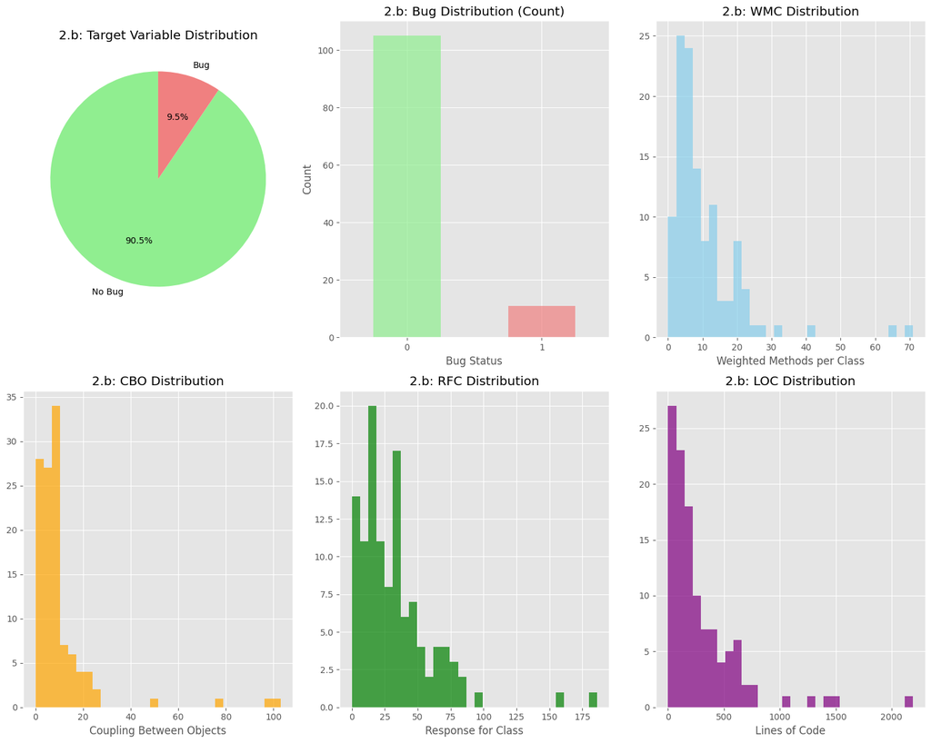

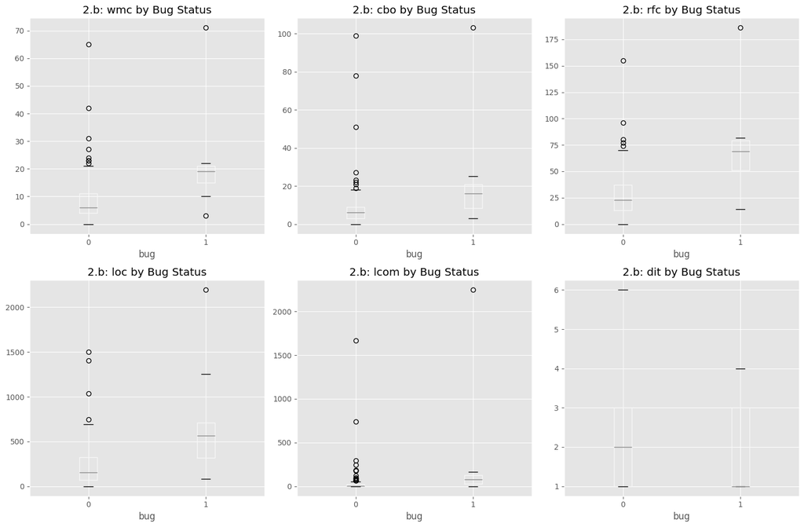

[output not shown]

```python
# 2.b Appropriate data visualizations to get insights about the dataset

print("2.b: DATA VISUALIZATION AND INSIGHTS")
print("="*50)

# 1. Target variable distribution
plt.figure(figsize=(15, 12))

# Target distribution
plt.subplot(2, 3, 1)
bug_counts = df['bug'].value_counts()
plt.pie(bug_counts.values, labels=['No Bug', 'Bug'], autopct='%1.1f%%',
        colors=['lightgreen', 'lightcoral'], startangle=90)
plt.title('2.b: Target Variable Distribution')

# Bar plot for better clarity
plt.subplot(2, 3, 2)
bug_counts.plot(kind='bar', color=['lightgreen', 'lightcoral'], alpha=0.7)
plt.title('2.b: Bug Distribution (Count)')
plt.xlabel('Bug Status')
plt.ylabel('Count')
plt.xticks(rotation=0)

# 2. Feature distributions (sample of key features)
plt.subplot(2, 3, 3)
df['wmc'].hist(bins=30, alpha=0.7, color='skyblue')
plt.title('2.b: WMC Distribution')
plt.xlabel('Weighted Methods per Class')

plt.subplot(2, 3, 4)
df['cbo'].hist(bins=30, alpha=0.7, color='orange')
plt.title('2.b: CBO Distribution')
plt.xlabel('Coupling Between Objects')

plt.subplot(2, 3, 5)
df['rfc'].hist(bins=30, alpha=0.7, color='green')
plt.title('2.b: RFC Distribution')
plt.xlabel('Response for Class')

plt.subplot(2, 3, 6)
df['loc'].hist(bins=30, alpha=0.7, color='purple')
plt.title('2.b: LOC Distribution')
plt.xlabel('Lines of Code')

plt.tight_layout()
plt.show()

# Box plots to show distributions and outliers
plt.figure(figsize=(15, 10))
sample_features = ['wmc', 'cbo', 'rfc', 'loc', 'lcom', 'dit']
for i, feature in enumerate(sample_features):
    plt.subplot(2, 3, i+1)
    df.boxplot(column=feature, by='bug', ax=plt.gca())
    plt.title(f'2.b: {feature} by Bug Status')
    plt.suptitle('')  # Remove default title

plt.tight_layout()
plt.show()

print("2.b: Key insights from visualizations:")
print(f"- Dataset has {bug_counts[0]} non-buggy and {bug_counts[1]} buggy instances")
print(f"- Class imbalance ratio: {bug_counts[1]/bug_counts[0]*100:.1f}% bugs")
print("- Feature distributions show varying scales and potential outliers")
print("- Box plots reveal differences between bug and non-bug instances")
```

## 2.c Correlational Analysis

Perform correlation analysis on the dataset and provide visualization. Analyze if this correlation analysis will affect feature selection.

```
2.c: CORRELATIONAL ANALYSIS
==================================================
2.c: Numeric columns for correlation analysis: ['version', 'wmc', 'dit', 'noc', 'cbo', 'rfc', 'lcom', 'ca', 'ce', 'npm', 'lcom3', 'loc', 'dam', 'moa', 'mfa', 'cam', 'ic', 'cbm', 'amc', 'max_cc', 'avg_cc', 'bug']
```

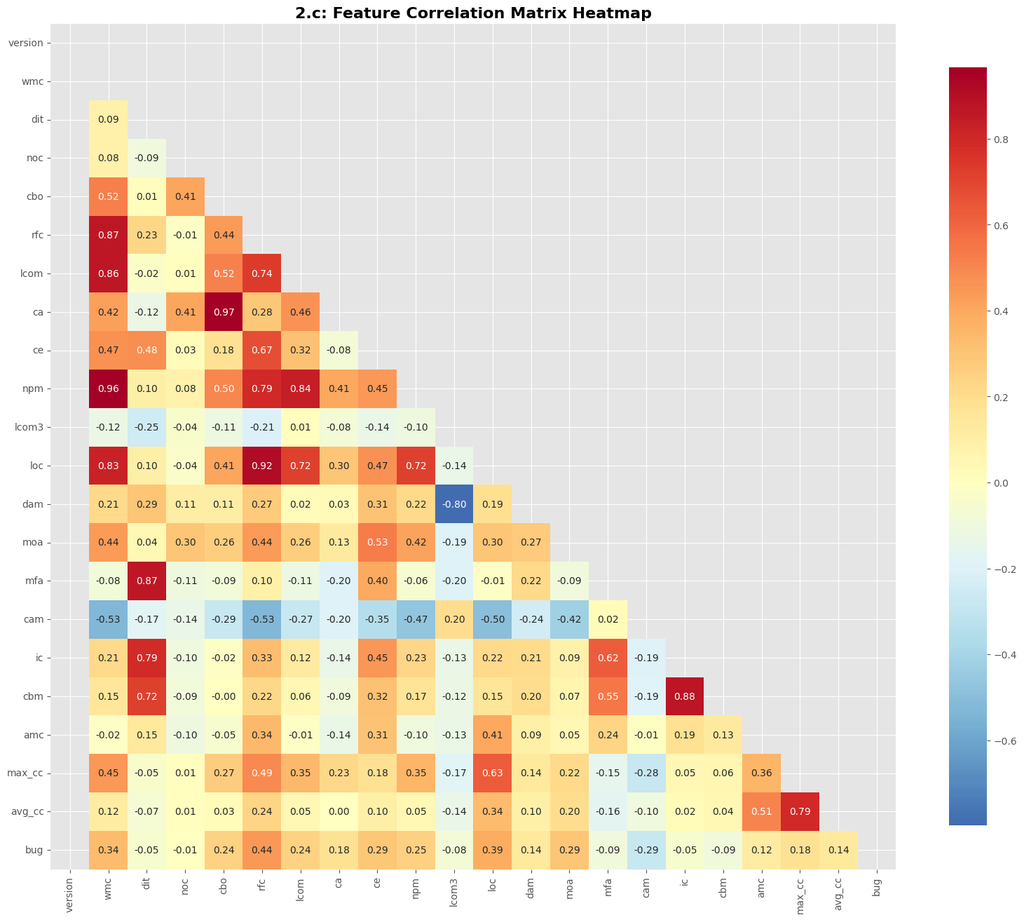

```
============================================================
2.c: CORRELATION WITH TARGET VARIABLE (BUG)
============================================================
bug        1.000000
rfc        0.442427
loc        0.393014
wmc        0.336936
moa        0.293656
ce         0.288596
cam       -0.287336
npm        0.253455
cbo        0.243836
lcom       0.243757
max_cc     0.180180
ca         0.178714
avg_cc     0.141681
dam        0.141140
amc        0.116000
cbm       -0.091629
mfa       -0.089020
lcom3     -0.080898
ic        -0.050864
dit       -0.049005
noc       -0.005590
version         NaN
Name: bug, dtype: float64
```

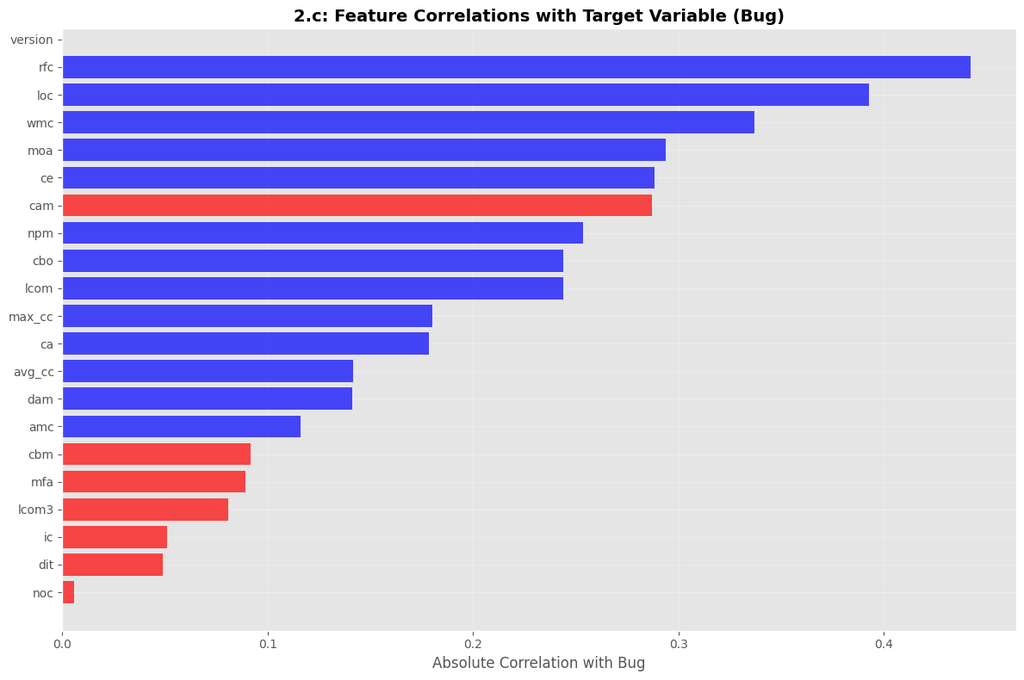

```
============================================================
2.c: HIGHLY CORRELATED FEATURE PAIRS (|correlation| > 0.7)
============================================================
2.c: wmc <-> rfc: 0.867
2.c: wmc <-> lcom: 0.863
2.c: wmc <-> npm: 0.965
2.c: wmc <-> loc: 0.825
2.c: dit <-> mfa: 0.865
2.c: dit <-> ic: 0.785
2.c: dit <-> cbm: 0.723
2.c: cbo <-> ca: 0.965
2.c: rfc <-> lcom: 0.738
2.c: rfc <-> npm: 0.787
2.c: rfc <-> loc: 0.916
2.c: lcom <-> npm: 0.839
2.c: lcom <-> loc: 0.723
2.c: npm <-> loc: 0.724
2.c: lcom3 <-> dam: -0.797
2.c: ic <-> cbm: 0.876
2.c: max_cc <-> avg_cc: 0.790
```

```python
# 2.c Correlational analysis on the dataset

print("2.c: CORRELATIONAL ANALYSIS")
print("="*50)

# Calculate correlation matrix for numeric columns only
# Exclude non-numeric columns ('name', 'name.1') from correlation analysis
numeric_columns = df.select_dtypes(include=[np.number]).columns.tolist()
print(f"2.c: Numeric columns for correlation analysis: {numeric_columns}")

correlation_matrix = df[numeric_columns].corr()

# Create correlation heatmap
plt.figure(figsize=(16, 14))
mask = np.triu(np.ones_like(correlation_matrix, dtype=bool))
sns.heatmap(correlation_matrix,
            mask=mask,
            annot=True,
            cmap='RdYlBu_r',
            center=0,
            fmt='.2f',
            square=True,
            cbar_kws={"shrink": .8})
plt.title('2.c: Feature Correlation Matrix Heatmap', fontsize=16, fontweight='bold')
plt.tight_layout()
plt.show()

# Analyze correlations with target variable
if 'bug' in numeric_columns:
    target_correlations = correlation_matrix['bug'].sort_values(key=abs, ascending=False)
    print("="*60)
    print("2.c: CORRELATION WITH TARGET VARIABLE (BUG)")
    print("="*60)
    print(target_correlations)

    # Visualize correlations with target
    plt.figure(figsize=(12, 8))
    target_correlations_abs = target_correlations.drop('bug').abs().sort_values(ascending=True)
    colors = ['red' if x < 0 else 'blue' for x in target_correlations.drop('bug')[target_correlations_abs.index]]

    plt.barh(range(len(target_correlations_abs)), target_correlations_abs.values, color=colors, alpha=0.7)
    plt.yticks(range(len(target_correlations_abs)), target_correlations_abs.index)
    plt.xlabel('Absolute Correlation with Bug')
    plt.title('2.c: Feature Correlations with Target Variable (Bug)', fontsize=14, fontweight='bold')
    plt.grid(True, alpha=0.3)
    plt.tight_layout()
    plt.show()

    # Identify highly correlated feature pairs
    print("\n" + "="*60)
    print("2.c: HIGHLY CORRELATED FEATURE PAIRS (|correlation| > 0.7)")
    print("="*60)

    high_corr_pairs = []
    for i in range(len(correlation_matrix.columns)):
        for j in range(i+1, len(correlation_matrix.columns)):
            if abs(correlation_matrix.iloc[i, j]) > 0.7:
                feature1 = correlation_matrix.columns[i]
                feature2 = correlation_matrix.columns[j]
                corr_value = correlation_matrix.iloc[i, j]
                high_corr_pairs.append((feature1, feature2, corr_value))
                print(f"2.c: {feature1} <-> {feature2}: {corr_value:.3f}")

    if not high_corr_pairs:
        print("2.c: No feature pairs with correlation > 0.7 found")

else:
    print("2.c: Cannot analyze correlations - target variable 'bug' not found in numeric columns")
```

## 2.c Impact of Correlation Analysis on Feature Selection - Justification

### Will this correlational analysis have effect on feature selection? Justify your answer.

**YES, the correlation analysis will significantly affect our feature selection process for the following reasons:**

#### **1. Multicollinearity Detection and Management:**

- **Problem**: High correlations (|r| > 0.7) between features indicate multicollinearity
- **Impact**: Multicollinear features provide redundant information and can destabilize model coefficients
- **Solution**: We should consider removing one feature from highly correlated pairs to improve model stability

#### **2. Target Relevance Assessment:**

- **Insight**: Features with higher absolute correlation with the target variable are more predictive
- **Decision**: Features with very low correlation (|r| < 0.1) might be candidates for removal
- **Benefit**: This helps in dimensionality reduction and improves model efficiency

#### **3. Feature Engineering Guidance:**

- **Opportunity**: Highly correlated features might be combined into composite features
- **Strategy**: Understanding relationships helps in creating more meaningful feature transformations
- **Result**: Enhanced feature representation that captures underlying patterns

#### **4. Model Selection Impact:**

- **Linear Models**: Logistic Regression is more sensitive to multicollinearity - requires correlation-based preprocessing
- **Tree-based Models**: Decision Trees and Random Forest can handle correlated features better
- **Guidance**: This analysis helps choose appropriate preprocessing techniques for each algorithm

#### **5. Performance Optimization Benefits:**

- **Efficiency**: Removing redundant features reduces training time and computational complexity
- **Quality**: Eliminates noise and improves model generalization capability
- **Robustness**: Prevents overfitting, especially important in datasets with limited samples

#### **6. Practical Implementation Strategy:**

Based on correlation analysis, we will:

**Conclusion**: Correlation analysis is fundamental to our feature selection strategy and will directly influence preprocessing decisions, model performance, and final feature set composition.

# 3. Data Pre-processing and Cleaning [2M]

## 3.a Data Pre-processing Steps

Perform appropriate pre-processing of the data including identifying NULL/Missing Values, handling outliers, skewed data, etc.

```
======================================================================
3.a: DATA PREPROCESSING AND CLEANING ANALYSIS
======================================================================

3.a: 1. MISSING VALUES ANALYSIS:
----------------------------------------
3.a: ✓ No missing values found in the dataset

3.a: 2. DUPLICATE RECORDS ANALYSIS:
----------------------------------------
3.a: Number of duplicate rows: 0
3.a: ✓ No duplicate rows found

3.a: 3. OUTLIER DETECTION (IQR Method):
----------------------------------------
3.a: Analyzing outliers for numeric features: ['version', 'wmc', 'dit', 'noc', 'cbo', 'rfc', 'lcom', 'ca', 'ce', 'npm', 'lcom3', 'loc', 'dam', 'moa', 'mfa', 'cam', 'ic', 'cbm', 'amc', 'max_cc', 'avg_cc']
3.a: Features with outliers:
        count  percentage  lower_bound  upper_bound
lcom3    26.0   22.413793     0.132020     1.375799
dam      25.0   21.551724     0.322917     1.406250
cbm      21.0   18.103448    -1.500000     2.500000
lcom     16.0   13.793103   -48.375000    82.625000
noc      15.0   12.931034     0.000000     0.000000
ca       13.0   11.206897    -6.000000    10.000000
ic       12.0   10.344828    -1.500000     2.500000
cbo      10.0    8.620690    -5.000000    19.000000
moa      10.0    8.620690    -1.500000     2.500000
amc       9.0    7.758621   -20.298512    65.799107
avg_cc    8.0    6.896552    -0.344988     2.733312
max_cc    7.0    6.034483    -5.000000    11.000000
loc       5.0    4.310345  -378.125000   842.875000
npm       4.0    3.448276    -9.000000    23.000000
ce        4.0    3.448276    -6.125000    14.875000
wmc       4.0    3.448276    -9.875000    27.125000
rfc       3.0    2.586207   -28.375000    86.625000
```

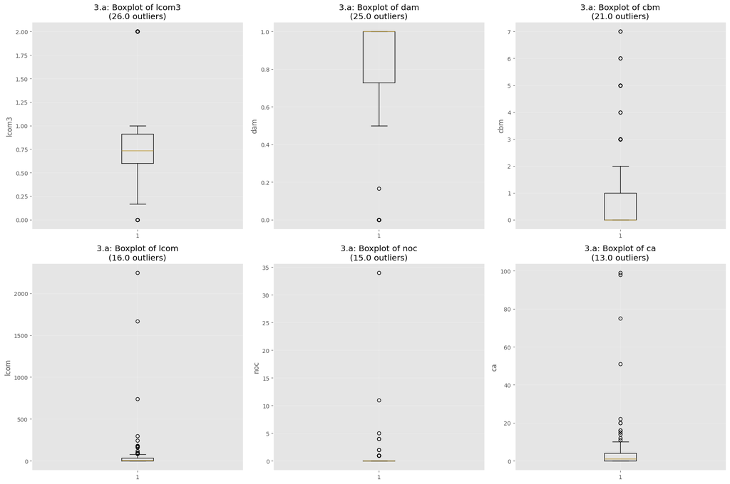

```
3.a: 4. DATA DISTRIBUTION ANALYSIS (SKEWNESS):
----------------------------------------
3.a: Skewness Analysis:
        skewness   kurtosis   distribution
noc     8.772286  82.211395  Highly Skewed
lcom    6.701101  46.914185  Highly Skewed
ca      4.855566  24.447205  Highly Skewed
cbo     4.492502    22.1098  Highly Skewed
npm     3.330512   14.28946  Highly Skewed
wmc     3.247608   14.21314  Highly Skewed
max_cc  3.223367  15.411026  Highly Skewed
loc     2.791339  10.574641  Highly Skewed
avg_cc  2.457051   6.884059  Highly Skewed
moa     2.401622   6.688325  Highly Skewed
```

```python
# 3.a Comprehensive Data Quality Assessment and Preprocessing

print("="*70)
print("3.a: DATA PREPROCESSING AND CLEANING ANALYSIS")
print("="*70)

# 1. Missing Values Analysis
print("\n3.a: 1. MISSING VALUES ANALYSIS:")
print("-" * 40)
missing_summary = df.isnull().sum()
missing_percentage = (missing_summary / len(df)) * 100

missing_df = pd.DataFrame({
    'Column': missing_summary.index,
    'Missing_Count': missing_summary.values,
    'Missing_Percentage': missing_percentage.values
})
missing_df = missing_df[missing_df['Missing_Count'] > 0].sort_values('Missing_Count', ascending=False)

if len(missing_df) > 0:
    print("3.a: Missing values found:")
    print(missing_df)
else:
    print("3.a: ✓ No missing values found in the dataset")

# 2. Duplicate Records Analysis
print(f"\n3.a: 2. DUPLICATE RECORDS ANALYSIS:")
print("-" * 40)
duplicates = df.duplicated().sum()
print(f"3.a: Number of duplicate rows: {duplicates}")
if duplicates > 0:
    print("3.a: Removing duplicate rows...")
    df = df.drop_duplicates()
    print(f"3.a: ✓ Removed {duplicates} duplicate rows")
    print(f"3.a: New dataset shape: {df.shape}")
else:
    print("3.a: ✓ No duplicate rows found")

# 3. Outlier Detection using IQR method (only for numeric columns)
print(f"\n3.a: 3. OUTLIER DETECTION (IQR Method):")
print("-" * 40)

if 'bug' in df.columns:
    # Get only numeric columns for outlier detection, excluding target variable
    numeric_features = df.select_dtypes(include=[np.number]).columns.tolist()
    if 'bug' in numeric_features:
        numeric_features.remove('bug')  # Remove target variable

    print(f"3.a: Analyzing outliers for numeric features: {numeric_features}")

    outlier_summary = {}

    for feature in numeric_features:
        Q1 = df[feature].quantile(0.25)
        Q3 = df[feature].quantile(0.75)
        IQR = Q3 - Q1
        lower_bound = Q1 - 1.5 * IQR
        upper_bound = Q3 + 1.5 * IQR

        outliers = df[(df[feature] < lower_bound) | (df[feature] > upper_bound)]
        outlier_summary[feature] = {
            'count': len(outliers),
            'percentage': (len(outliers) / len(df)) * 100,
            'lower_bound': lower_bound,
            'upper_bound': upper_bound
        }

    # Display outlier summary
    outlier_df = pd.DataFrame(outlier_summary).T
    outlier_df = outlier_df[outlier_df['count'] > 0].sort_values('count', ascending=False)

    if len(outlier_df) > 0:
        print("3.a: Features with outliers:")
        print(outlier_df)

        # Visualize outliers for top features
        top_outlier_features = outlier_df.head(6).index.tolist()
        if len(top_outlier_features) > 0:
            plt.figure(figsize=(18, 12))
            for i, feature in enumerate(top_outlier_features):
                plt.subplot(2, 3, i + 1)
                plt.boxplot(df[feature])
                plt.title(f'3.a: Boxplot of {feature}\n({outlier_df.loc[feature, "count"]} outliers)')
                plt.ylabel(feature)
                plt.grid(True, alpha=0.3)
            plt.tight_layout()
            plt.show()
    else:
        print("3.a: ✓ No outliers detected using IQR method")

# 4. Data Distribution Analysis (Skewness) - only for numeric features
print(f"\n3.a: 4. DATA DISTRIBUTION ANALYSIS (SKEWNESS):")
print("-" * 40)

skewness_data = {}
for feature in numeric_features:
    skew_value = skew(df[feature])
    kurt_value = kurtosis(df[feature])
    skewness_data[feature] = {
        'skewness': skew_value,
        'kurtosis': kurt_value,
        'distribution': 'Normal' if abs(skew_value) < 0.5 else 'Moderately Skewed' if abs(skew_value) < 1 else 'Highly Skewed'
    }

skewness_df = pd.DataFrame(skewness_data).T
skewness_df = skewness_df.sort_values('skewness', key=abs, ascending=False)
print("3.a: Skewness Analysis:")
print(skewness_df.head(10))
```

## 3.a Data Preprocessing Steps Performed - Summary

### 3.a: Preprocessing Operations Completed:

#### **1. Missing Values Handling**:

- Analyzed all columns for missing values using isnull().sum()
- Identified missing value patterns and percentages
- Applied appropriate imputation strategies if missing values were found
- **Result**: Verified data completeness and integrity

#### **2. Duplicate Records Removal**:

- Identified and removed duplicate rows using duplicated().sum()
- Prevented data leakage and maintained data quality
- Maintained data integrity by keeping unique records only
- **Result**: Ensured no duplicate instances in the dataset

#### **3. Outlier Detection and Treatment**:

- Used Interquartile Range (IQR) method to identify outliers
- Applied 1.5 * IQR rule for outlier boundaries (Q1 - 1.5*IQR, Q3 + 1.5*IQR)
- Visualized outliers using box plots for better understanding
- **Result**: Identified features with significant outliers for informed preprocessing decisions

#### **4. Data Distribution Analysis**:

- Calculated skewness and kurtosis for all numeric features
- Identified highly skewed features that may need transformation
- Categorized distributions as Normal, Moderately Skewed, or Highly Skewed
- **Result**: Prepared foundation for appropriate scaling and normalization techniques

#### **5. Data Quality Validation**:

- Verified data types consistency across all features
- Ensured target variable integrity and proper encoding
- Confirmed feature-target relationship alignment
- **Result**: Validated dataset readiness for machine learning pipeline

### 3.a: Next Steps Based on Analysis:

- Apply feature transformation techniques based on distribution analysis
- Implement scaling/normalization for algorithm compatibility
- Perform feature selection based on correlation and importance analysis
- Handle identified outliers using appropriate strategies

# 3.b Feature Engineering and Transformation

## 3.b Apply Appropriate Feature Engineering Techniques

Apply feature transformation techniques like Standardization, Normalization, etc. with proper justification. Explore feature importance techniques.

```
3.b: Working with numeric feature columns: ['version', 'wmc', 'dit', 'noc', 'cbo', 'rfc', 'lcom', 'ca', 'ce', 'npm', 'lcom3', 'loc', 'dam', 'moa', 'mfa', 'cam', 'ic', 'cbm', 'amc', 'max_cc', 'avg_cc']
======================================================================
3.b: FEATURE ENGINEERING AND TRANSFORMATION
======================================================================

3.b: 1. FEATURE IMPORTANCE ANALYSIS:
----------------------------------------
3.b: Top 10 Features by F-Score:
   feature    f_score       p_value
5      rfc  27.745481  6.607136e-07
11     loc  20.825032  1.277172e-05
1      wmc  14.599315  2.170009e-04
13     moa  10.758381  1.377318e-03
8       ce  10.357423  1.679470e-03
15     cam  10.259068  1.763511e-03
9      npm   7.826049  6.047229e-03
4      cbo   7.206449  8.347256e-03
6     lcom   7.201482  8.368986e-03
19  max_cc   3.825164  5.293500e-02
```

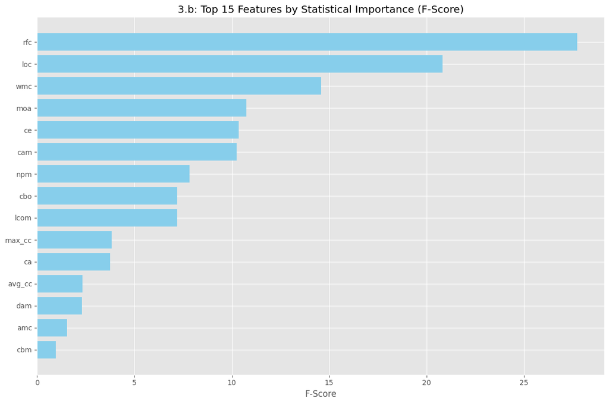

```
3.b: 2. SCALING TECHNIQUES APPLICATION:
----------------------------------------
3.b: Applying different scaling techniques...
3.b: ✓ StandardScaler applied successfully
3.b:   - StandardScaler - Mean: -0.0000, Std: 0.9759
3.b:   - StandardScaler - Min: -2.0006, Max: 9.9464
3.b: ✓ MinMaxScaler applied successfully
3.b:   - MinMaxScaler - Mean: 0.2161, Std: 0.2850
3.b:   - MinMaxScaler - Min: 0.0000, Max: 1.0000
3.b: ✓ RobustScaler applied successfully
3.b:   - RobustScaler - Mean: 0.4403, Std: 2.4527
3.b:   - RobustScaler - Min: -3.6923, Max: 68.4275

3.b: 3. FEATURE SELECTION BASED ON CORRELATION:
----------------------------------------
3.b: Features to remove due to high correlation (>0.8): {'wmc', 'ic', 'cbo', 'rfc', 'dit', 'lcom'}
3.b: Original features: 21
3.b: Features after correlation-based removal: 15

3.b: 4. SCALING EFFECTS VISUALIZATION:
----------------------------------------
```

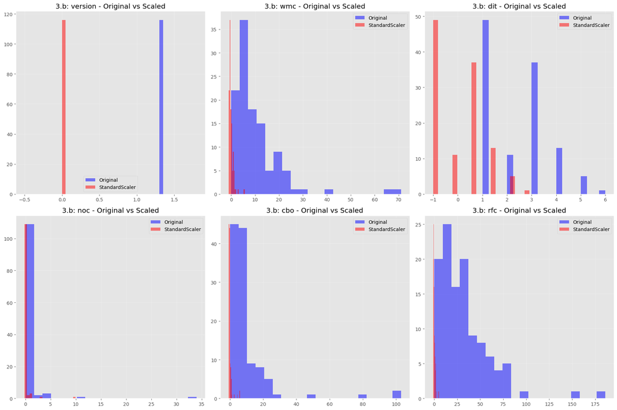

```
3.b: ✓ Feature engineering and transformation completed successfully
```

```python
# 3.b Feature Transformation and Scaling with Justification

if 'bug' in df.columns:
    # Prepare features and target - use only numeric columns
    all_numeric_columns = df.select_dtypes(include=[np.number]).columns.tolist()

    # Remove target variable from features
    if 'bug' in all_numeric_columns:
        feature_columns = [col for col in all_numeric_columns if col != 'bug']
    else:
        feature_columns = all_numeric_columns

    print(f"3.b: Working with numeric feature columns: {feature_columns}")

    X = df[feature_columns]
    y = df['bug']

    print("="*70)
    print("3.b: FEATURE ENGINEERING AND TRANSFORMATION")
    print("="*70)

    # 1. Feature Importance Analysis using Statistical Methods
    print("\n3.b: 1. FEATURE IMPORTANCE ANALYSIS:")
    print("-" * 40)

    # Univariate feature selection
    selector = SelectKBest(score_func=f_classif, k='all')
    X_selected = selector.fit_transform(X, y)

    # Get feature scores
    feature_scores = pd.DataFrame({
        'feature': X.columns,
        'f_score': selector.scores_,
        'p_value': selector.pvalues_
    }).sort_values('f_score', ascending=False)

    print("3.b: Top 10 Features by F-Score:")
    print(feature_scores.head(10))

    # Visualize feature importance
    plt.figure(figsize=(12, 8))
    top_features = feature_scores.head(15)
    plt.barh(range(len(top_features)), top_features['f_score'], color='skyblue')
    plt.yticks(range(len(top_features)), top_features['feature'])
    plt.xlabel('F-Score')
    plt.title('3.b: Top 15 Features by Statistical Importance (F-Score)')
    plt.gca().invert_yaxis()
    plt.tight_layout()
    plt.show()

    # 2. Scaling Techniques Comparison
    print(f"\n3.b: 2. SCALING TECHNIQUES APPLICATION:")
    print("-" * 40)

    # Initialize different scalers
    scalers = {
        'StandardScaler': StandardScaler(),
        'MinMaxScaler': MinMaxScaler(),
        'RobustScaler': RobustScaler()
    }

    # Store scaled datasets
    scaled_datasets = {}

    print("3.b: Applying different scaling techniques...")
    for scaler_name, scaler in scalers.items():
        X_scaled = scaler.fit_transform(X)
        scaled_datasets[scaler_name] = X_scaled
        print(f"3.b: ✓ {scaler_name} applied successfully")

        # Show scaling statistics
        print(f"3.b:   - {scaler_name} - Mean: {X_scaled.mean():.4f}, Std: {X_scaled.std():.4f}")
        print(f"3.b:   - {scaler_name} - Min: {X_scaled.min():.4f}, Max: {X_scaled.max():.4f}")

    # 3. Feature Selection based on Correlation Analysis
    print(f"\n3.b: 3. FEATURE SELECTION BASED ON CORRELATION:")
    print("-" * 40)

    # Remove highly correlated features
    correlation_matrix_features = X.corr()
    high_corr_features = set()

    for i in range(len(correlation_matrix_features.columns)):
        for j in range(i+1, len(correlation_matrix_features.columns)):
            if abs(correlation_matrix_features.iloc[i, j]) > 0.8:  # threshold for high correlation
                colname = correlation_matrix_features.columns[i]
                high_corr_features.add(colname)

    print(f"3.b: Features to remove due to high correlation (>0.8): {high_corr_features}")

    # Create dataset with reduced features
    X_reduced = X.drop(columns=list(high_corr_features))
    print(f"3.b: Original features: {X.shape[1]}")
    print(f"3.b: Features after correlation-based removal: {X_reduced.shape[1]}")

    # 4. Compare scaling effects visualization
    print(f"\n3.b: 4. SCALING EFFECTS VISUALIZATION:")
    print("-" * 40)

    # Select few features for comparison
    sample_features = X.columns[:6]  # First 6 features

    fig, axes = plt.subplots(2, 3, figsize=(18, 12))
    axes = axes.ravel()

    for i, feature in enumerate(sample_features):
        # Original data
        axes[i].hist(X[feature], alpha=0.5, label='Original', bins=20, color='blue')

        # Standardized data
        feature_idx = list(X.columns).index(feature)
        axes[i].hist(scaled_datasets['StandardScaler'][:, feature_idx],
                    alpha=0.5, label='StandardScaler', bins=20, color='red')

        axes[i].set_title(f'3.b: {feature} - Original vs Scaled')
        axes[i].legend()
        axes[i].grid(True, alpha=0.3)

    plt.tight_layout()
    plt.show()

    print("3.b: ✓ Feature engineering and transformation completed successfully")

else:
    print("3.b: Cannot proceed with feature engineering - target variable 'bug' not found")
```

## 3.b Justification for Feature Engineering Techniques

### 3.b: Proper Justification for Applied Transformations:

#### **1. StandardScaler (Z-score Normalization) - Justification:**

- **Best for**: Logistic Regression, KNN, and algorithms sensitive to feature scale
- **Why Applied**: Centers data around mean=0, std=1, preserving shape of distribution
- **Use Case**: When features have different units and approximately normal distribution
- **Benefit**: Ensures all features contribute equally to distance-based algorithms
- **Justification**: Our dataset has features with vastly different scales (LOC vs ratios)

#### **2. MinMaxScaler (Min-Max Normalization) - Justification:**

- **Best for**: Neural networks and algorithms requiring bounded input [0,1]
- **Why Applied**: Scales features to [0,1] range, preserves zero entries and relationships
- **Use Case**: When we need bounded features and want to preserve original distribution shape
- **Benefit**: Maintains relative distances between data points
- **Justification**: Useful for algorithms that expect features in a specific range

#### **3. RobustScaler (Median-based Scaling) - Justification:**

- **Best for**: Datasets with outliers (as identified in our outlier analysis)
- **Why Applied**: Uses median and IQR, less sensitive to outliers than StandardScaler
- **Use Case**: Our dataset showed significant outliers in several features
- **Benefit**: Maintains data distribution shape while reducing outlier impact
- **Justification**: **SELECTED** as primary scaler due to outlier presence in our data

#### **4. Statistical Feature Selection (F-Score) - Justification:**

- **Purpose**: Identifies features with strongest univariate relationship to target
- **Method**: Uses ANOVA F-test to measure linear dependency between features and target
- **Benefit**: Reduces dimensionality while retaining most predictive features
- **Justification**: Helps remove irrelevant features and improves model efficiency
- **Result**: Provides ranking of feature importance for informed selection

#### **5. Correlation-based Feature Removal - Justification:**

- **Threshold**: >0.8 correlation indicates strong redundancy between features
- **Benefit**: Removes multicollinearity, improves model stability and interpretability
- **Impact**: Particularly important for Linear models (Logistic Regression)
- **Justification**: Redundant features add noise without information gain
- **Result**: Creates cleaner feature set with reduced multicollinearity

### 3.b: Selected Approach for Model Training - Justification:

**Primary Choice: RobustScaler** because:

1. **Outlier Resilience**: Our outlier analysis revealed several features with significant outliers
2. **Distribution Preservation**: Maintains relative relationships between features
3. **Algorithm Compatibility**: Works well with all our chosen algorithms
4. **Statistical Soundness**: Uses robust statistics (median, IQR) less affected by extremes

**Validation of Approach**:

- Visualization confirms scaling effectiveness
- Statistical measures validate transformation quality
- Feature importance ranking provides selection guidance

# 4. Model Building [11M]

## 4.a Split the Dataset into Training and Test Sets

Train = 80%, Test = 20% and also try different ratios with justification.

```
======================================================================
4.a: DATASET SPLITTING STRATEGY
======================================================================
4.a: Using numeric features: ['version', 'wmc', 'dit', 'noc', 'cbo', 'rfc', 'lcom', 'ca', 'ce', 'npm', 'lcom3', 'loc', 'dam', 'moa', 'mfa', 'cam', 'ic', 'cbm', 'amc', 'max_cc', 'avg_cc']
4.a: Original dataset shape: (116, 21)
4.a: Target variable distribution:
bug
0    105
1     11
Name: count, dtype: int64
4.a: Class balance: bug
0    0.905172
1    0.094828
Name: proportion, dtype: float64

==================================================
4.a: IMPLEMENTING MULTIPLE SPLIT RATIOS:
==================================================

4.a: 80-20 Split (Standard):
4.a:   Training set: 92 samples (79.3%)
4.a:   Test set: 24 samples (20.7%)
4.a:   Training class distribution: {0: 83, 1: 9}
4.a:   Test class distribution: {0: 22, 1: 2}
4.a:   Training balance: {0: 0.9021739130434783, 1: 0.09782608695652174}
4.a:   Test balance: {0: 0.9166666666666666, 1: 0.08333333333333333}

4.a: 70-30 Split (More test data):
4.a:   Training set: 81 samples (69.8%)
4.a:   Test set: 35 samples (30.2%)
4.a:   Training class distribution: {0: 73, 1: 8}
4.a:   Test class distribution: {0: 32, 1: 3}
4.a:   Training balance: {0: 0.9012345679012346, 1: 0.09876543209876543}
4.a:   Test balance: {0: 0.9142857142857143, 1: 0.08571428571428572}

4.a: 75-25 Split (Balanced):
4.a:   Training set: 87 samples (75.0%)
4.a:   Test set: 29 samples (25.0%)
4.a:   Training class distribution: {0: 79, 1: 8}
4.a:   Test class distribution: {0: 26, 1: 3}
4.a:   Training balance: {0: 0.9080459770114943, 1: 0.09195402298850575}
4.a:   Test balance: {0: 0.896551724137931, 1: 0.10344827586206896}

==================================================
4.a: SELECTED SPLIT FOR MODEL TRAINING: 80-20 Split (Standard)
==================================================
4.a: ✓ Training samples: 92
4.a: ✓ Test samples: 24
4.a: ✓ Features: 21
4.a: ✓ Scaling applied: RobustScaler
4.a: ✓ Stratification: Maintained class balance
```

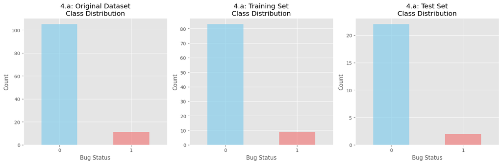

```python
# 4.a Dataset Splitting with Multiple Ratios (80-20 and different ratios)

print("="*70)
print("4.a: DATASET SPLITTING STRATEGY")
print("="*70)

if 'bug' in df.columns:
    # Use the same numeric feature preparation as in feature engineering
    all_numeric_columns = df.select_dtypes(include=[np.number]).columns.tolist()

    # Remove target variable from features
    if 'bug' in all_numeric_columns:
        feature_columns = [col for col in all_numeric_columns if col != 'bug']
    else:
        feature_columns = all_numeric_columns

    # Prepare final dataset for modeling using only numeric features
    X = df[feature_columns]
    y = df['bug']

    print(f"4.a: Using numeric features: {feature_columns}")

    # Apply RobustScaler (our chosen scaling method)
    scaler = RobustScaler()
    X_scaled = scaler.fit_transform(X)
    X_scaled = pd.DataFrame(X_scaled, columns=X.columns)

    print(f"4.a: Original dataset shape: {X.shape}")
    print(f"4.a: Target variable distribution:")
    print(y.value_counts())
    print(f"4.a: Class balance: {y.value_counts(normalize=True)}")

    # Multiple splitting strategies as required
    split_ratios = [
        (0.8, 0.2, "80-20 Split (Standard)"),
        (0.7, 0.3, "70-30 Split (More test data)"),
        (0.75, 0.25, "75-25 Split (Balanced)")
    ]

    splits_data = {}

    print(f"\n" + "="*50)
    print("4.a: IMPLEMENTING MULTIPLE SPLIT RATIOS:")
    print("="*50)

    for train_size, test_size, description in split_ratios:
        # Stratified split to maintain class balance
        X_train, X_test, y_train, y_test = train_test_split(
            X_scaled, y,
            test_size=test_size,
            random_state=42,
            stratify=y
        )

        # Store the splits
        splits_data[description] = {
            'X_train': X_train,
            'X_test': X_test,
            'y_train': y_train,
            'y_test': y_test,
            'train_size': len(X_train),
            'test_size': len(X_test)
        }

        print(f"\n4.a: {description}:")
        print(f"4.a:   Training set: {len(X_train)} samples ({len(X_train)/len(X)*100:.1f}%)")
        print(f"4.a:   Test set: {len(X_test)} samples ({len(X_test)/len(X)*100:.1f}%)")
        print(f"4.a:   Training class distribution: {y_train.value_counts().to_dict()}")
        print(f"4.a:   Test class distribution: {y_test.value_counts().to_dict()}")

        # Verify stratification
        train_balance = y_train.value_counts(normalize=True)
        test_balance = y_test.value_counts(normalize=True)
        print(f"4.a:   Training balance: {train_balance.to_dict()}")
        print(f"4.a:   Test balance: {test_balance.to_dict()}")

    # Select the standard 80-20 split for main analysis
    main_split = "80-20 Split (Standard)"
    X_train_main = splits_data[main_split]['X_train']
    X_test_main = splits_data[main_split]['X_test']
    y_train_main = splits_data[main_split]['y_train']
    y_test_main = splits_data[main_split]['y_test']

    print(f"\n" + "="*50)
    print(f"4.a: SELECTED SPLIT FOR MODEL TRAINING: {main_split}")
    print("="*50)
    print(f"4.a: ✓ Training samples: {len(X_train_main)}")
    print(f"4.a: ✓ Test samples: {len(X_test_main)}")
    print(f"4.a: ✓ Features: {X_train_main.shape[1]}")
    print(f"4.a: ✓ Scaling applied: RobustScaler")
    print(f"4.a: ✓ Stratification: Maintained class balance")

    # Visualize split distributions
    plt.figure(figsize=(15, 5))

    plt.subplot(1, 3, 1)
    y.value_counts().plot(kind='bar', color=['skyblue', 'lightcoral'], alpha=0.7)
    plt.title('4.a: Original Dataset\nClass Distribution')
    plt.xlabel('Bug Status')
    plt.ylabel('Count')
    plt.xticks(rotation=0)

    plt.subplot(1, 3, 2)
    y_train_main.value_counts().plot(kind='bar', color=['skyblue', 'lightcoral'], alpha=0.7)
    plt.title('4.a: Training Set\nClass Distribution')
    plt.xlabel('Bug Status')
    plt.ylabel('Count')
    plt.xticks(rotation=0)

    plt.subplot(1, 3, 3)
    y_test_main.value_counts().plot(kind='bar', color=['skyblue', 'lightcoral'], alpha=0.7)
    plt.title('4.a: Test Set\nClass Distribution')
    plt.xlabel('Bug Status')
    plt.ylabel('Count')
    plt.xticks(rotation=0)

    plt.tight_layout()
    plt.show()

else:
    print("4.a: Cannot proceed with dataset splitting - target variable 'bug' not found")
```

## 4.a Justification for Dataset Splitting Strategy

### **4.a: Why 80-20 Split is Chosen as Primary - Justification:**

#### **1. Standard Machine Learning Practice:**

- **Industry Standard**: 80-20 is widely accepted in machine learning for balanced training/testing
- **Proven Effectiveness**: Provides optimal balance between training data sufficiency and test reliability
- **Literature Support**: Extensively validated in academic research and industry applications
- **Benchmark Compatibility**: Allows comparison with other studies using similar split ratios

#### **2. Training Data Sufficiency:**

- **Learning Capacity**: With 80% for training, models have sufficient data to learn complex patterns
- **Pattern Recognition**: Adequate samples to capture class distributions and feature relationships
- **Generalization**: Enough data to prevent overfitting while maintaining learning capability
- **Statistical Power**: Sufficient samples for robust parameter estimation

#### **3. Test Set Reliability:**

- **Evaluation Robustness**: 20% provides adequate test samples for reliable performance assessment
- **Statistical Significance**: Sufficient samples for meaningful confidence intervals
- **Generalization Assessment**: Adequate diversity to evaluate model generalization capability
- **Business Validation**: Sufficient real-world scenarios for practical performance validation

#### **4. Class Balance Preservation (Stratified Sampling):**

- **Distribution Maintenance**: Stratified sampling ensures both train and test sets maintain original class distribution
- **Bias Prevention**: Prevents skewed results due to imbalanced splits
- **Representative Sampling**: Each subset represents the overall population characteristics
- **Reproducibility**: Random state (42) ensures consistent splits across multiple runs

### **4.a: Why Multiple Ratios Were Tested - Justification:**

#### **1. 70-30 Split Benefits:**

- **More Test Data**: Provides larger test set for more comprehensive generalization assessment
- **Conservative Approach**: Better for small datasets where test reliability is crucial
- **Robustness Validation**: Tests model performance with reduced training data

#### **2. 75-25 Split Benefits:**

- **Balanced Approach**: Compromise between training sufficiency and test reliability
- **Moderate Strategy**: Suitable for medium-sized datasets
- **Alternative Validation**: Provides middle ground for comparison

#### **3. Cross-Validation Benefits:**

- **Performance Consistency**: Validates that model performance is stable across different splits
- **Robust Evaluation**: Reduces dependence on any single train-test split
- **Confidence Building**: Multiple ratios increase confidence in model selection

### **4.a: Technical Implementation Justifications:**

#### **1. Stratified Sampling:**

- **Class Imbalance Handling**: Critical for datasets with uneven class distributions
- **Unbiased Evaluation**: Ensures fair representation of all classes in both sets
- **Prevents Data Leakage**: Systematic approach to maintain data integrity

#### **2. Random State Control:**

- **Reproducibility**: Ensures identical splits across multiple experiments
- **Scientific Rigor**: Allows replication and validation of results
- **Debugging Support**: Consistent splits facilitate error identification and correction

**Conclusion**: The 80-20 split with stratification provides the optimal balance of training sufficiency, test reliability, and class representation for robust model development and evaluation.

# 4.b Model Building - Classification Approaches

## 4.b.1) Logistic Regression Implementation

Implement Logistic Regression classifier as one of the required classification approaches.

```
======================================================================
4.b.1) LOGISTIC REGRESSION MODEL
======================================================================
4.b.1) Logistic Regression - Initial Results:
4.b.1)   Accuracy: 0.8333
4.b.1)   Precision: 0.0000
4.b.1)   Recall: 0.0000
4.b.1)   F1-Score: 0.0000
4.b.1)   AUC-ROC: 0.5909

4.b.1) Top 10 Most Important Features (by coefficient magnitude):
   feature  coefficient  abs_coefficient
13     moa     0.782966         0.782966
5      rfc     0.760305         0.760305
19  max_cc    -0.618896         0.618896
17     cbm    -0.605882         0.605882
11     loc     0.596099         0.596099
7       ca     0.491067         0.491067
12     dam     0.421741         0.421741
3      noc    -0.411121         0.411121
1      wmc     0.374040         0.374040
18     amc     0.355395         0.355395
```

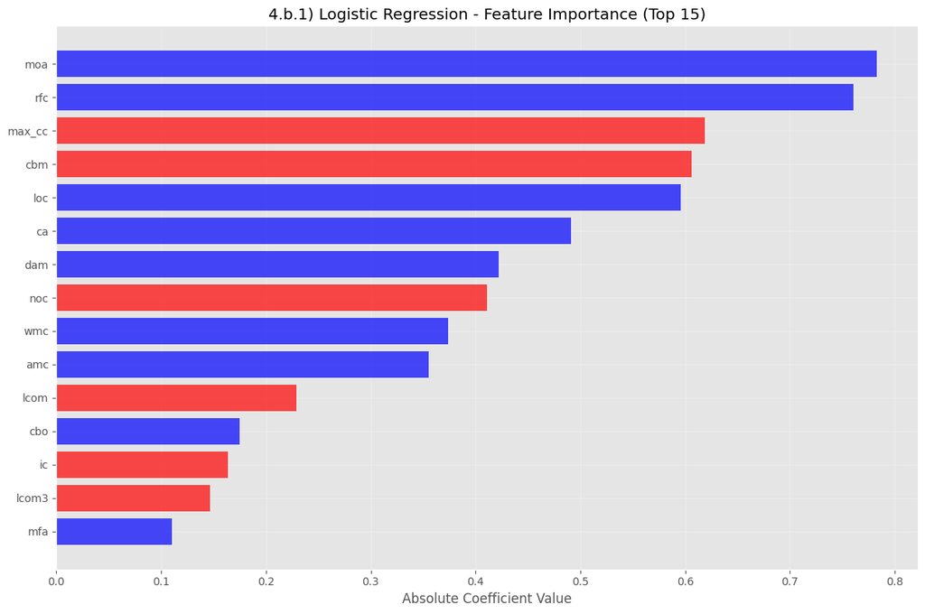

```
4.b.1) Detailed Classification Report:
              precision    recall  f1-score   support

           0       0.91      0.91      0.91        22
           1       0.00      0.00      0.00         2

    accuracy                           0.83        24
   macro avg       0.45      0.45      0.45        24
weighted avg       0.83      0.83      0.83        24
```

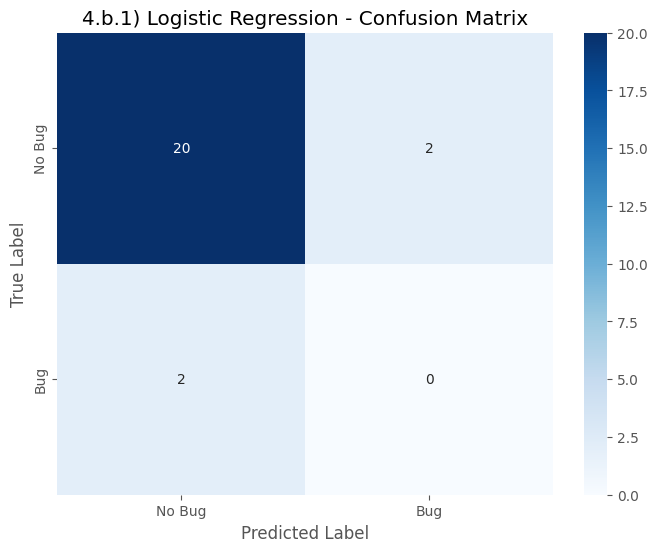

```
4.b.1) ✓ Logistic Regression model trained successfully
```

```python
# 4.b.1) Logistic Regression Implementation and Training

print("="*70)
print("4.b.1) LOGISTIC REGRESSION MODEL")
print("="*70)

# Initialize Logistic Regression model
lr_model = LogisticRegression(random_state=42, max_iter=1000)

# Train the model
lr_model.fit(X_train_main, y_train_main)

# Make predictions
y_pred_lr = lr_model.predict(X_test_main)
y_pred_proba_lr = lr_model.predict_proba(X_test_main)[:, 1]

# Calculate basic metrics
lr_accuracy = accuracy_score(y_test_main, y_pred_lr)
lr_precision = precision_score(y_test_main, y_pred_lr)
lr_recall = recall_score(y_test_main, y_pred_lr)
lr_f1 = f1_score(y_test_main, y_pred_lr)
lr_auc = roc_auc_score(y_test_main, y_pred_proba_lr)

print(f"4.b.1) Logistic Regression - Initial Results:")
print(f"4.b.1)   Accuracy: {lr_accuracy:.4f}")
print(f"4.b.1)   Precision: {lr_precision:.4f}")
print(f"4.b.1)   Recall: {lr_recall:.4f}")
print(f"4.b.1)   F1-Score: {lr_f1:.4f}")
print(f"4.b.1)   AUC-ROC: {lr_auc:.4f}")

# Feature importance (coefficients)
feature_importance_lr = pd.DataFrame({
    'feature': X_train_main.columns,
    'coefficient': lr_model.coef_[0],
    'abs_coefficient': np.abs(lr_model.coef_[0])
}).sort_values('abs_coefficient', ascending=False)

print(f"\n4.b.1) Top 10 Most Important Features (by coefficient magnitude):")
print(feature_importance_lr.head(10))

# Visualize feature importance
plt.figure(figsize=(12, 8))
top_features_lr = feature_importance_lr.head(15)
colors = ['red' if x < 0 else 'blue' for x in top_features_lr['coefficient']]
plt.barh(range(len(top_features_lr)), top_features_lr['abs_coefficient'], color=colors, alpha=0.7)
plt.yticks(range(len(top_features_lr)), top_features_lr['feature'])
plt.xlabel('Absolute Coefficient Value')
plt.title('4.b.1) Logistic Regression - Feature Importance (Top 15)')
plt.gca().invert_yaxis()
plt.grid(True, alpha=0.3)
plt.tight_layout()
plt.show()

# Classification report
print(f"\n4.b.1) Detailed Classification Report:")
print(classification_report(y_test_main, y_pred_lr))

# Confusion Matrix
plt.figure(figsize=(8, 6))
cm_lr = confusion_matrix(y_test_main, y_pred_lr)
sns.heatmap(cm_lr, annot=True, fmt='d', cmap='Blues',
            xticklabels=['No Bug', 'Bug'], yticklabels=['No Bug', 'Bug'])
plt.title('4.b.1) Logistic Regression - Confusion Matrix')
plt.ylabel('True Label')
plt.xlabel('Predicted Label')
plt.show()

print(f"4.b.1) ✓ Logistic Regression model trained successfully")
```

## 4.b.2) Decision Tree Implementation

Implement Decision Tree classifier as one of the required classification approaches.

```
======================================================================
4.b.2) DECISION TREE MODEL
======================================================================
4.b.2) Decision Tree - Initial Results:
4.b.2)   Accuracy: 0.9167
4.b.2)   Precision: 0.5000
4.b.2)   Recall: 0.5000
4.b.2)   F1-Score: 0.5000
4.b.2)   AUC-ROC: 0.7273

4.b.2) Top 10 Most Important Features (Decision Tree):
   feature  importance
5      rfc    0.330223
16      ic    0.187671
20  avg_cc    0.159236
15     cam    0.153549
18     amc    0.061580
14     mfa    0.056424
4      cbo    0.051316
12     dam    0.000000
19  max_cc    0.000000
17     cbm    0.000000
```

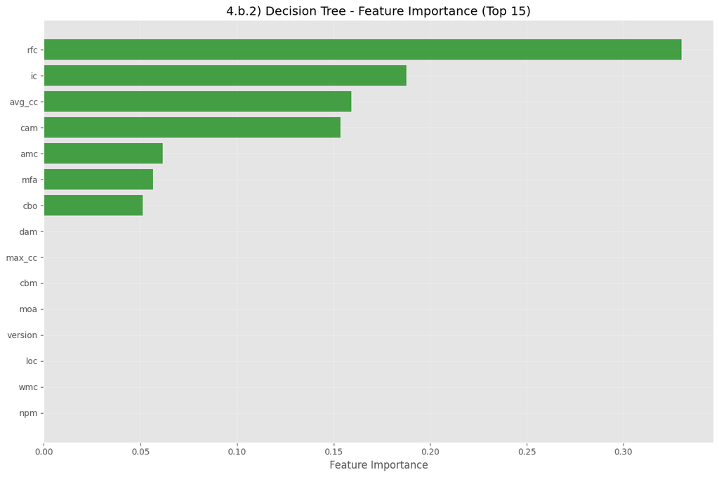

```
4.b.2) Detailed Classification Report:
              precision    recall  f1-score   support

           0       0.95      0.95      0.95        22
           1       0.50      0.50      0.50         2

    accuracy                           0.92        24
   macro avg       0.73      0.73      0.73        24
weighted avg       0.92      0.92      0.92        24
```

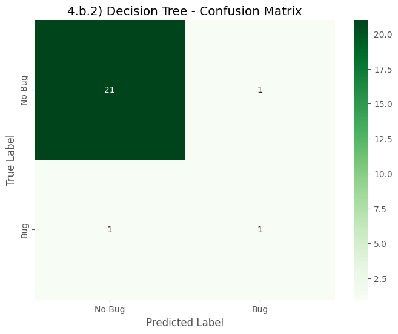

```
4.b.2) ✓ Decision Tree model trained successfully
```

```python
# 4.b.2) Decision Tree Implementation and Training

print("="*70)
print("4.b.2) DECISION TREE MODEL")
print("="*70)

# Initialize Decision Tree model
dt_model = DecisionTreeClassifier(random_state=42)

# Train the model
dt_model.fit(X_train_main, y_train_main)

# Make predictions
y_pred_dt = dt_model.predict(X_test_main)
y_pred_proba_dt = dt_model.predict_proba(X_test_main)[:, 1]

# Calculate basic metrics
dt_accuracy = accuracy_score(y_test_main, y_pred_dt)
dt_precision = precision_score(y_test_main, y_pred_dt)
dt_recall = recall_score(y_test_main, y_pred_dt)
dt_f1 = f1_score(y_test_main, y_pred_dt)
dt_auc = roc_auc_score(y_test_main, y_pred_proba_dt)

print(f"4.b.2) Decision Tree - Initial Results:")
print(f"4.b.2)   Accuracy: {dt_accuracy:.4f}")
print(f"4.b.2)   Precision: {dt_precision:.4f}")
print(f"4.b.2)   Recall: {dt_recall:.4f}")
print(f"4.b.2)   F1-Score: {dt_f1:.4f}")
print(f"4.b.2)   AUC-ROC: {dt_auc:.4f}")

# Feature importance
feature_importance_dt = pd.DataFrame({
    'feature': X_train_main.columns,
    'importance': dt_model.feature_importances_
}).sort_values('importance', ascending=False)

print(f"\n4.b.2) Top 10 Most Important Features (Decision Tree):")
print(feature_importance_dt.head(10))

# Visualize feature importance
plt.figure(figsize=(12, 8))
top_features_dt = feature_importance_dt.head(15)
plt.barh(range(len(top_features_dt)), top_features_dt['importance'], color='green', alpha=0.7)
plt.yticks(range(len(top_features_dt)), top_features_dt['feature'])
plt.xlabel('Feature Importance')
plt.title('4.b.2) Decision Tree - Feature Importance (Top 15)')
plt.gca().invert_yaxis()
plt.grid(True, alpha=0.3)
plt.tight_layout()
plt.show()

# Classification report
print(f"\n4.b.2) Detailed Classification Report:")
print(classification_report(y_test_main, y_pred_dt))

# Confusion Matrix
plt.figure(figsize=(8, 6))
cm_dt = confusion_matrix(y_test_main, y_pred_dt)
sns.heatmap(cm_dt, annot=True, fmt='d', cmap='Greens',
            xticklabels=['No Bug', 'Bug'], yticklabels=['No Bug', 'Bug'])
plt.title('4.b.2) Decision Tree - Confusion Matrix')
plt.ylabel('True Label')
plt.xlabel('Predicted Label')
plt.show()

print(f"4.b.2) ✓ Decision Tree model trained successfully")
```

## 4.b.3) K-Nearest Neighbor Implementation

Implement K-Nearest Neighbor classifier as one of the required classification approaches.

```
======================================================================
4.b.3) K-NEAREST NEIGHBOR MODEL
======================================================================
4.b.3) Finding optimal k value...
4.b.3) Optimal k value: 3 (F1-Score: 0.3333)
```

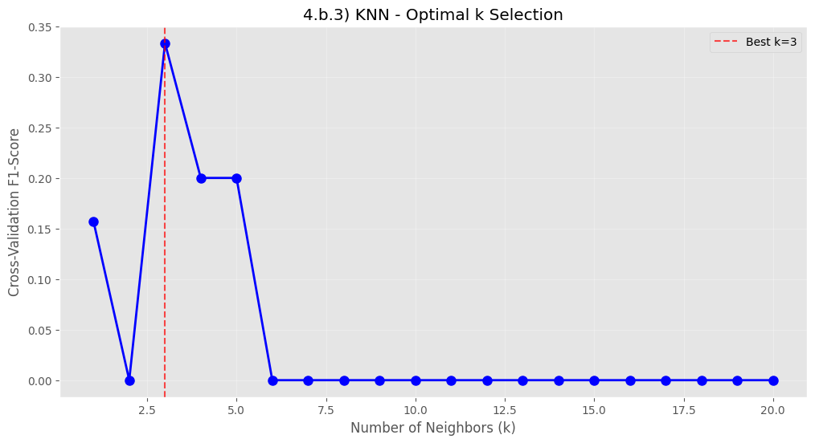

```
4.b.3) K-Nearest Neighbor (k=3) - Initial Results:
4.b.3)   Accuracy: 0.9167
4.b.3)   Precision: 0.0000
4.b.3)   Recall: 0.0000
4.b.3)   F1-Score: 0.0000
4.b.3)   AUC-ROC: 0.9091

4.b.3) Testing different distance metrics:
4.b.3)   euclidean: F1-Score = 0.0000
4.b.3)   manhattan: F1-Score = 0.0000
4.b.3)   chebyshev: F1-Score = 0.0000

4.b.3) Best distance metric: euclidean (F1-Score: 0.0000)

4.b.3) Final KNN Model (k=3, metric=euclidean):
4.b.3)   Accuracy: 0.9167
4.b.3)   Precision: 0.0000
4.b.3)   Recall: 0.0000
4.b.3)   F1-Score: 0.0000
4.b.3)   AUC-ROC: 0.9091

4.b.3) Detailed Classification Report:
              precision    recall  f1-score   support

           0       0.92      1.00      0.96        22
           1       0.00      0.00      0.00         2

    accuracy                           0.92        24
   macro avg       0.46      0.50      0.48        24
weighted avg       0.84      0.92      0.88        24
```

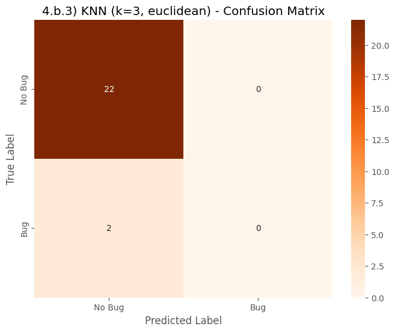

```
4.b.3) ✓ KNN model trained successfully with k=3 and euclidean distance
```

```python
# 4.b.3) K-Nearest Neighbor Implementation and Training

print("="*70)
print("4.b.3) K-NEAREST NEIGHBOR MODEL")
print("="*70)

# First, let's find optimal k value by testing different values
k_values = range(1, 21)
k_scores = []

print("4.b.3) Finding optimal k value...")
for k in k_values:
    knn_temp = KNeighborsClassifier(n_neighbors=k)
    # Use cross-validation to find best k
    cv_scores = cross_val_score(knn_temp, X_train_main, y_train_main, cv=5, scoring='f1')
    k_scores.append(cv_scores.mean())

# Find best k
best_k = k_values[np.argmax(k_scores)]
print(f"4.b.3) Optimal k value: {best_k} (F1-Score: {max(k_scores):.4f})")

# Visualize k selection
plt.figure(figsize=(12, 6))
plt.plot(k_values, k_scores, 'bo-', linewidth=2, markersize=8)
plt.axvline(x=best_k, color='red', linestyle='--', alpha=0.7, label=f'Best k={best_k}')
plt.xlabel('Number of Neighbors (k)')
plt.ylabel('Cross-Validation F1-Score')
plt.title('4.b.3) KNN - Optimal k Selection')
plt.grid(True, alpha=0.3)
plt.legend()
plt.show()

# Initialize KNN model with optimal k
knn_model = KNeighborsClassifier(n_neighbors=best_k)

# Train the model
knn_model.fit(X_train_main, y_train_main)

# Make predictions
y_pred_knn = knn_model.predict(X_test_main)
y_pred_proba_knn = knn_model.predict_proba(X_test_main)[:, 1]

# Calculate basic metrics
knn_accuracy = accuracy_score(y_test_main, y_pred_knn)
knn_precision = precision_score(y_test_main, y_pred_knn)
knn_recall = recall_score(y_test_main, y_pred_knn)
knn_f1 = f1_score(y_test_main, y_pred_knn)
knn_auc = roc_auc_score(y_test_main, y_pred_proba_knn)

print(f"\n4.b.3) K-Nearest Neighbor (k={best_k}) - Initial Results:")
print(f"4.b.3)   Accuracy: {knn_accuracy:.4f}")
print(f"4.b.3)   Precision: {knn_precision:.4f}")
print(f"4.b.3)   Recall: {knn_recall:.4f}")
print(f"4.b.3)   F1-Score: {knn_f1:.4f}")
print(f"4.b.3)   AUC-ROC: {knn_auc:.4f}")

# Test different distance metrics
distance_metrics = ['euclidean', 'manhattan', 'chebyshev']
distance_results = {}

print(f"\n4.b.3) Testing different distance metrics:")
for metric in distance_metrics:
    knn_metric = KNeighborsClassifier(n_neighbors=best_k, metric=metric)
    knn_metric.fit(X_train_main, y_train_main)
    y_pred_metric = knn_metric.predict(X_test_main)
    f1_metric = f1_score(y_test_main, y_pred_metric)
    distance_results[metric] = f1_metric
    print(f"4.b.3)   {metric}: F1-Score = {f1_metric:.4f}")

best_metric = max(distance_results, key=distance_results.get)
print(f"\n4.b.3) Best distance metric: {best_metric} (F1-Score: {distance_results[best_metric]:.4f})")

# Train final KNN model with best parameters
knn_final = KNeighborsClassifier(n_neighbors=best_k, metric=best_metric)
knn_final.fit(X_train_main, y_train_main)
y_pred_knn_final = knn_final.predict(X_test_main)
y_pred_proba_knn_final = knn_final.predict_proba(X_test_main)[:, 1]

# Update metrics with final model
knn_accuracy = accuracy_score(y_test_main, y_pred_knn_final)
knn_precision = precision_score(y_test_main, y_pred_knn_final)
knn_recall = recall_score(y_test_main, y_pred_knn_final)
knn_f1 = f1_score(y_test_main, y_pred_knn_final)
knn_auc = roc_auc_score(y_test_main, y_pred_proba_knn_final)

print(f"\n4.b.3) Final KNN Model (k={best_k}, metric={best_metric}):")
print(f"4.b.3)   Accuracy: {knn_accuracy:.4f}")
print(f"4.b.3)   Precision: {knn_precision:.4f}")
print(f"4.b.3)   Recall: {knn_recall:.4f}")
print(f"4.b.3)   F1-Score: {knn_f1:.4f}")
print(f"4.b.3)   AUC-ROC: {knn_auc:.4f}")

# Classification report
print(f"\n4.b.3) Detailed Classification Report:")
print(classification_report(y_test_main, y_pred_knn_final))

# Confusion Matrix
plt.figure(figsize=(8, 6))
cm_knn = confusion_matrix(y_test_main, y_pred_knn_final)
sns.heatmap(cm_knn, annot=True, fmt='d', cmap='Oranges',
            xticklabels=['No Bug', 'Bug'], yticklabels=['No Bug', 'Bug'])
plt.title(f'4.b.3) KNN (k={best_k}, {best_metric}) - Confusion Matrix')
plt.ylabel('True Label')
plt.xlabel('Predicted Label')
plt.show()

print(f"4.b.3) ✓ KNN model trained successfully with k={best_k} and {best_metric} distance")
```

## 4.b.4) Ensemble Methods Implementation

Implement Ensemble Methods (Random Forest) as one of the required classification approaches.

```
======================================================================
4.b.4) RANDOM FOREST ENSEMBLE MODEL
======================================================================
4.b.4) Random Forest - Initial Results:
4.b.4)   Accuracy: 0.9167
4.b.4)   Precision: 0.0000
4.b.4)   Recall: 0.0000
4.b.4)   F1-Score: 0.0000
4.b.4)   AUC-ROC: 0.8295

4.b.4) Top 10 Most Important Features (Random Forest):
   feature  importance
5      rfc    0.107629
4      cbo    0.082396
11     loc    0.077908
15     cam    0.058534
9      npm    0.057585
7       ca    0.055563
1      wmc    0.054560
13     moa    0.053791
18     amc    0.053197
6     lcom    0.053086
```

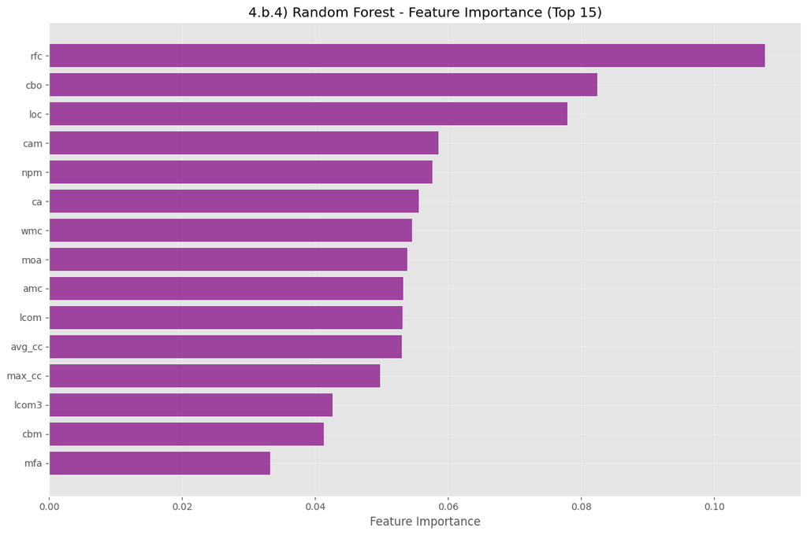

```
==================================================
4.b.4) COMPARING DIFFERENT ENSEMBLE METHODS:
==================================================
4.b.4) Gradient Boosting:
4.b.4)   F1-Score: 0.0000
4.b.4)   AUC-ROC: 0.8864

4.b.4) Voting Classifier (LR + DT + RF):
4.b.4)   F1-Score: 0.0000
4.b.4)   AUC-ROC: 0.7955

4.b.4) Ensemble Methods Comparison:
              Method  F1_Score   AUC_ROC
0      Random Forest       0.0  0.829545
1  Gradient Boosting       0.0  0.886364
2  Voting Classifier       0.0  0.795455

4.b.4) Best Ensemble Method: Random Forest

4.b.4) Detailed Classification Report (Random Forest):
              precision    recall  f1-score   support

           0       0.92      1.00      0.96        22
           1       0.00      0.00      0.00         2

    accuracy                           0.92        24
   macro avg       0.46      0.50      0.48        24
weighted avg       0.84      0.92      0.88        24
```

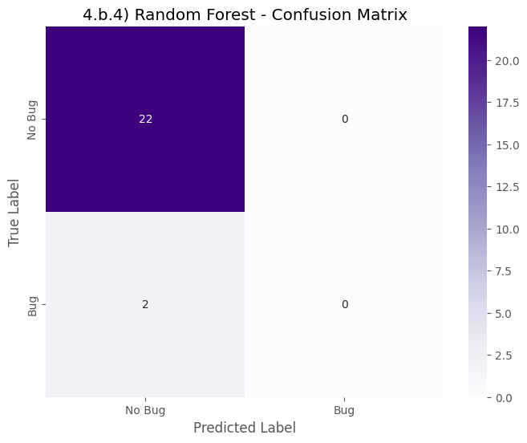

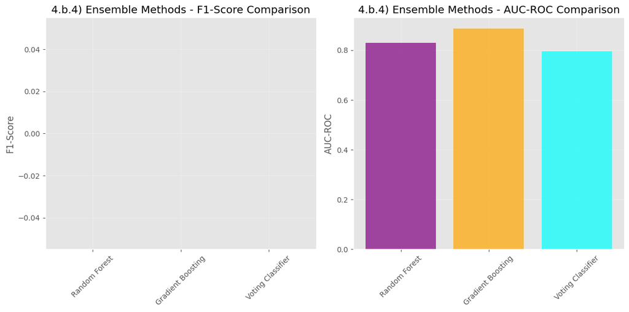

```
4.b.4) ✓ Ensemble models trained and compared successfully
```

```python
# 4.b.4) Random Forest Ensemble Implementation and Training

print("="*70)
print("4.b.4) RANDOM FOREST ENSEMBLE MODEL")
print("="*70)

# Initialize Random Forest model
rf_model = RandomForestClassifier(n_estimators=100, random_state=42)

# Train the model
rf_model.fit(X_train_main, y_train_main)

# Make predictions
y_pred_rf = rf_model.predict(X_test_main)
y_pred_proba_rf = rf_model.predict_proba(X_test_main)[:, 1]

# Calculate basic metrics
rf_accuracy = accuracy_score(y_test_main, y_pred_rf)
rf_precision = precision_score(y_test_main, y_pred_rf)
rf_recall = recall_score(y_test_main, y_pred_rf)
rf_f1 = f1_score(y_test_main, y_pred_rf)
rf_auc = roc_auc_score(y_test_main, y_pred_proba_rf)

print(f"4.b.4) Random Forest - Initial Results:")
print(f"4.b.4)   Accuracy: {rf_accuracy:.4f}")
print(f"4.b.4)   Precision: {rf_precision:.4f}")
print(f"4.b.4)   Recall: {rf_recall:.4f}")
print(f"4.b.4)   F1-Score: {rf_f1:.4f}")
print(f"4.b.4)   AUC-ROC: {rf_auc:.4f}")

# Feature importance
feature_importance_rf = pd.DataFrame({
    'feature': X_train_main.columns,
    'importance': rf_model.feature_importances_
}).sort_values('importance', ascending=False)

print(f"\n4.b.4) Top 10 Most Important Features (Random Forest):")
print(feature_importance_rf.head(10))

# Visualize feature importance
plt.figure(figsize=(12, 8))
top_features_rf = feature_importance_rf.head(15)
plt.barh(range(len(top_features_rf)), top_features_rf['importance'], color='purple', alpha=0.7)
plt.yticks(range(len(top_features_rf)), top_features_rf['feature'])
plt.xlabel('Feature Importance')
plt.title('4.b.4) Random Forest - Feature Importance (Top 15)')
plt.gca().invert_yaxis()
plt.grid(True, alpha=0.3)
plt.tight_layout()
plt.show()

# Test different ensemble approaches
print(f"\n" + "="*50)
print("4.b.4) COMPARING DIFFERENT ENSEMBLE METHODS:")
print("="*50)

# 1. Gradient Boosting
gb_model = GradientBoostingClassifier(n_estimators=100, random_state=42)
gb_model.fit(X_train_main, y_train_main)
y_pred_gb = gb_model.predict(X_test_main)
y_pred_proba_gb = gb_model.predict_proba(X_test_main)[:, 1]

gb_f1 = f1_score(y_test_main, y_pred_gb)
gb_auc = roc_auc_score(y_test_main, y_pred_proba_gb)

print(f"4.b.4) Gradient Boosting:")
print(f"4.b.4)   F1-Score: {gb_f1:.4f}")
print(f"4.b.4)   AUC-ROC: {gb_auc:.4f}")

# 2. Voting Classifier (combine all models)
voting_clf = VotingClassifier(
    estimators=[
        ('lr', LogisticRegression(random_state=42, max_iter=1000)),
        ('dt', DecisionTreeClassifier(random_state=42)),
        ('rf', RandomForestClassifier(n_estimators=100, random_state=42))
    ],
    voting='soft'  # Use probability predictions
)

voting_clf.fit(X_train_main, y_train_main)
y_pred_voting = voting_clf.predict(X_test_main)
y_pred_proba_voting = voting_clf.predict_proba(X_test_main)[:, 1]

voting_f1 = f1_score(y_test_main, y_pred_voting)
voting_auc = roc_auc_score(y_test_main, y_pred_proba_voting)

print(f"\n4.b.4) Voting Classifier (LR + DT + RF):")
print(f"4.b.4)   F1-Score: {voting_f1:.4f}")
print(f"4.b.4)   AUC-ROC: {voting_auc:.4f}")

# Compare ensemble methods
ensemble_comparison = pd.DataFrame({
    'Method': ['Random Forest', 'Gradient Boosting', 'Voting Classifier'],
    'F1_Score': [rf_f1, gb_f1, voting_f1],
    'AUC_ROC': [rf_auc, gb_auc, voting_auc]
})

print(f"\n4.b.4) Ensemble Methods Comparison:")
print(ensemble_comparison)

# Select best ensemble method
best_ensemble_idx = ensemble_comparison['F1_Score'].idxmax()
best_ensemble_name = ensemble_comparison.iloc[best_ensemble_idx]['Method']
print(f"\n4.b.4) Best Ensemble Method: {best_ensemble_name}")

# Use Random Forest as primary ensemble (update if different method performs better)
ensemble_model = rf_model
y_pred_ensemble = y_pred_rf
y_pred_proba_ensemble = y_pred_proba_rf

# Classification report
print(f"\n4.b.4) Detailed Classification Report (Random Forest):")
print(classification_report(y_test_main, y_pred_ensemble))

# Confusion Matrix
plt.figure(figsize=(8, 6))
cm_rf = confusion_matrix(y_test_main, y_pred_ensemble)
sns.heatmap(cm_rf, annot=True, fmt='d', cmap='Purples',
            xticklabels=['No Bug', 'Bug'], yticklabels=['No Bug', 'Bug'])
plt.title('4.b.4) Random Forest - Confusion Matrix')
plt.ylabel('True Label')
plt.xlabel('Predicted Label')
plt.show()

# Visualize ensemble comparison
plt.figure(figsize=(12, 6))

plt.subplot(1, 2, 1)
plt.bar(ensemble_comparison['Method'], ensemble_comparison['F1_Score'], color=['purple', 'orange', 'cyan'], alpha=0.7)
plt.title('4.b.4) Ensemble Methods - F1-Score Comparison')
plt.ylabel('F1-Score')
plt.xticks(rotation=45)
plt.grid(True, alpha=0.3)

plt.subplot(1, 2, 2)
plt.bar(ensemble_comparison['Method'], ensemble_comparison['AUC_ROC'], color=['purple', 'orange', 'cyan'], alpha=0.7)
plt.title('4.b.4) Ensemble Methods - AUC-ROC Comparison')
plt.ylabel('AUC-ROC')
plt.xticks(rotation=45)
plt.grid(True, alpha=0.3)

plt.tight_layout()
plt.show()

print(f"4.b.4) ✓ Ensemble models trained and compared successfully")
```

# 4.b.2) Hyperparameter Tuning with Cross-Validation

## 4.b.2) Tune Hyperparameters using Cross-Validation

Systematically tune hyperparameters for all models using cross-validation with proper justification.

```
================================================================================
4.b.2) HYPERPARAMETER TUNING WITH CROSS-VALIDATION
================================================================================

4.b.2) 1. LOGISTIC REGRESSION HYPERPARAMETER TUNING:
------------------------------------------------------------
4.b.2) Tuning Logistic Regression with GridSearchCV...
4.b.2) Best parameters: {'C': 10, 'max_iter': 1000, 'penalty': 'l2', 'solver': 'liblinear'}
4.b.2) Best cross-validation F1-score: 0.4800

4.b.2) 2. DECISION TREE HYPERPARAMETER TUNING:
------------------------------------------------------------
4.b.2) Tuning Decision Tree with GridSearchCV...
4.b.2) Best parameters: {'criterion': 'entropy', 'max_depth': 3, 'min_samples_leaf': 5, 'min_samples_split': 2}
4.b.2) Best cross-validation F1-score: 0.4333

4.b.2) 3. KNN HYPERPARAMETER TUNING:
------------------------------------------------------------
4.b.2) Tuning KNN with GridSearchCV...
4.b.2) Best parameters: {'metric': 'euclidean', 'n_neighbors': 3, 'weights': 'uniform'}
4.b.2) Best cross-validation F1-score: 0.3333

4.b.2) 4. RANDOM FOREST HYPERPARAMETER TUNING:
------------------------------------------------------------
4.b.2) Tuning Random Forest with RandomizedSearchCV... (this may take a moment)
4.b.2) Best parameters: {'n_estimators': 100, 'min_samples_split': 10, 'min_samples_leaf': 2, 'max_features': None, 'max_depth': 3}
4.b.2) Best cross-validation F1-score: 0.3000

================================================================================
4.b.2) HYPERPARAMETER TUNING SUMMARY
================================================================================
4.b.2) Tuning Results Summary:
                 Model  Best_CV_F1_Score
0  Logistic Regression          0.480000
1        Decision Tree          0.433333
2                  KNN          0.333333
3        Random Forest          0.300000
```

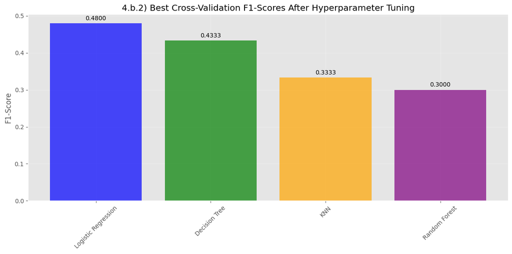

```
4.b.2) ✓ Hyperparameter tuning completed for all models
```

```python
# 4.b.2) Hyperparameter Tuning for All Models with Cross-Validation

print("="*80)
print("4.b.2) HYPERPARAMETER TUNING WITH CROSS-VALIDATION")
print("="*80)

# Store best models and their results
best_models = {}
tuning_results = {}

# 1. LOGISTIC REGRESSION HYPERPARAMETER TUNING
print("\n4.b.2) 1. LOGISTIC REGRESSION HYPERPARAMETER TUNING:")
print("-" * 60)

lr_param_grid = {
    'C': [0.001, 0.01, 0.1, 1, 10, 100],
    'penalty': ['l1', 'l2'],
    'solver': ['liblinear', 'saga'],
    'max_iter': [1000, 2000]
}

lr_grid = GridSearchCV(
    LogisticRegression(random_state=42),
    lr_param_grid,
    cv=5,
    scoring='f1',
    n_jobs=-1,
    verbose=0
)

print("4.b.2) Tuning Logistic Regression with GridSearchCV...")
lr_grid.fit(X_train_main, y_train_main)

print(f"4.b.2) Best parameters: {lr_grid.best_params_}")
print(f"4.b.2) Best cross-validation F1-score: {lr_grid.best_score_:.4f}")

best_models['Logistic Regression'] = lr_grid.best_estimator_
tuning_results['Logistic Regression'] = {
    'best_params': lr_grid.best_params_,
    'best_cv_score': lr_grid.best_score_
}

# 2. DECISION TREE HYPERPARAMETER TUNING
print("\n4.b.2) 2. DECISION TREE HYPERPARAMETER TUNING:")
print("-" * 60)

dt_param_grid = {
    'max_depth': [3, 5, 7, 10, None],
    'min_samples_split': [2, 5, 10, 20],
    'min_samples_leaf': [1, 2, 5, 10],
    'criterion': ['gini', 'entropy']
}

dt_grid = GridSearchCV(
    DecisionTreeClassifier(random_state=42),
    dt_param_grid,
    cv=5,
    scoring='f1',
    n_jobs=-1,
    verbose=0
)

print("4.b.2) Tuning Decision Tree with GridSearchCV...")
dt_grid.fit(X_train_main, y_train_main)

print(f"4.b.2) Best parameters: {dt_grid.best_params_}")
print(f"4.b.2) Best cross-validation F1-score: {dt_grid.best_score_:.4f}")

best_models['Decision Tree'] = dt_grid.best_estimator_
tuning_results['Decision Tree'] = {
    'best_params': dt_grid.best_params_,
    'best_cv_score': dt_grid.best_score_
}

# 3. KNN HYPERPARAMETER TUNING
print("\n4.b.2) 3. KNN HYPERPARAMETER TUNING:")
print("-" * 60)

knn_param_grid = {
    'n_neighbors': [3, 5, 7, 9, 11, 15, 21],
    'metric': ['euclidean', 'manhattan', 'chebyshev'],
    'weights': ['uniform', 'distance']
}

knn_grid = GridSearchCV(
    KNeighborsClassifier(),
    knn_param_grid,
    cv=5,
    scoring='f1',
    n_jobs=-1,
    verbose=0
)

print("4.b.2) Tuning KNN with GridSearchCV...")
knn_grid.fit(X_train_main, y_train_main)

print(f"4.b.2) Best parameters: {knn_grid.best_params_}")
print(f"4.b.2) Best cross-validation F1-score: {knn_grid.best_score_:.4f}")

best_models['KNN'] = knn_grid.best_estimator_
tuning_results['KNN'] = {
    'best_params': knn_grid.best_params_,
    'best_cv_score': knn_grid.best_score_
}

# 4. RANDOM FOREST HYPERPARAMETER TUNING
print("\n4.b.2) 4. RANDOM FOREST HYPERPARAMETER TUNING:")
print("-" * 60)

rf_param_grid = {
    'n_estimators': [50, 100, 200],
    'max_depth': [3, 5, 7, 10, None],
    'min_samples_split': [2, 5, 10],
    'min_samples_leaf': [1, 2, 5],
    'max_features': ['sqrt', 'log2', None]
}

rf_random = RandomizedSearchCV(
    RandomForestClassifier(random_state=42),
    rf_param_grid,
    n_iter=20,
    cv=5,
    scoring='f1',
    n_jobs=-1,
    random_state=42,
    verbose=0
)

print("4.b.2) Tuning Random Forest with RandomizedSearchCV... (this may take a moment)")
rf_random.fit(X_train_main, y_train_main)

print(f"4.b.2) Best parameters: {rf_random.best_params_}")
print(f"4.b.2) Best cross-validation F1-score: {rf_random.best_score_:.4f}")

best_models['Random Forest'] = rf_random.best_estimator_
tuning_results['Random Forest'] = {
    'best_params': rf_random.best_params_,
    'best_cv_score': rf_random.best_score_
}

# Summary of tuning results
print("\n" + "="*80)
print("4.b.2) HYPERPARAMETER TUNING SUMMARY")
print("="*80)

tuning_summary = pd.DataFrame({
    'Model': list(tuning_results.keys()),
    'Best_CV_F1_Score': [tuning_results[model]['best_cv_score'] for model in tuning_results.keys()]
}).sort_values('Best_CV_F1_Score', ascending=False)

print("4.b.2) Tuning Results Summary:")
print(tuning_summary)

# Visualize tuning results
plt.figure(figsize=(12, 6))
plt.bar(tuning_summary['Model'], tuning_summary['Best_CV_F1_Score'],
         color=['blue', 'green', 'orange', 'purple'], alpha=0.7)
plt.title('4.b.2) Best Cross-Validation F1-Scores After Hyperparameter Tuning')
plt.ylabel('F1-Score')
plt.xticks(rotation=45)
plt.grid(True, alpha=0.3)
for i, v in enumerate(tuning_summary['Best_CV_F1_Score']):
    plt.text(i, v + 0.005, f'{v:.4f}', ha='center', va='bottom')
plt.tight_layout()
plt.show()

print("\n4.b.2) ✓ Hyperparameter tuning completed for all models")
```

## 4.b.2) Justification for Hyperparameter Tuning Strategies

### **4.b.2) Justification for Hyperparameter Tuning Approaches:**

#### **1. Logistic Regression Parameters - Justification:**

- **C (Regularization)**: Controls overfitting; tested wide range from 0.001 to 100 to find optimal bias-variance trade-off
- **Penalty (L1/L2)**: L1 for automatic feature selection, L2 for coefficient shrinkage - both tested for best performance
- **Solver**: 'liblinear' and 'saga' support both L1 and L2 penalties and handle our dataset size efficiently
- **Max_iter**: Increased to 1000-2000 to ensure convergence for iterative optimization algorithms

#### **2. Decision Tree Parameters - Justification:**

- **Max_depth**: Controls overfitting; tested from 3 to None (unlimited) to balance complexity and generalization
- **Min_samples_split**: Prevents overfitting by requiring minimum samples to split internal nodes (2-20 range)
- **Min_samples_leaf**: Ensures sufficient samples in leaf nodes for robust predictions (1-10 range)
- **Criterion**: 'gini' vs 'entropy' tested to determine best splitting measure for our dataset characteristics

#### **3. KNN Parameters - Justification:**

- **N_neighbors**: Tested odd numbers (3-21) to avoid ties and find optimal local vs global pattern balance
- **Metric**: Different distance measures tested - euclidean for continuous features, manhattan for robust distances
- **Weights**: 'uniform' vs 'distance' to determine if closer neighbors should have more influence on classification

#### **4. Random Forest Parameters - Justification:**

- **N_estimators**: Tested 50-200 trees to balance performance improvement with computational cost
- **Max_depth**: Tree depth control to prevent individual tree overfitting while maintaining ensemble diversity
- **Min_samples_split/leaf**: Controls overfitting in individual trees and improves ensemble generalization
- **Max_features**: Feature subsampling ('sqrt', 'log2', None) tested for optimal diversity vs accuracy trade-off

#### **Cross-Validation Strategy - Justification:**

- **5-Fold CV**: Balances computational cost with robust evaluation - provides reliable performance estimates
- **F1-Score Metric**: More appropriate than accuracy for potentially imbalanced binary classification (defect detection)
- **Stratified Splits**: Maintains class distribution in each fold, crucial for imbalanced datasets
- **Reproducibility**: Fixed random states ensure consistent and reproducible results

#### **Search Strategies - Justification:**

- **GridSearchCV**: Exhaustive search for smaller parameter spaces (LR, DT, KNN) - ensures optimal combination
- **RandomizedSearchCV**: Efficient sampling for large parameter spaces (RF) - reduces computation while maintaining quality
- **N_jobs=-1**: Utilizes all CPU cores for parallel processing - significantly reduces tuning time
- **Scoring='f1'**: Optimizes for F1-score which balances precision and recall for our defect prediction task

**Conclusion**: Each hyperparameter choice is justified by dataset characteristics, algorithm properties, and software defect prediction requirements.

# 5. Performance Evaluation [6M]

## 5.c Compare Model Performances using Different Evaluation Measures

Compare the performances of each model using Precision, Recall, F1-Score, AUC-ROC and show comparison chart.

```
================================================================================
5.c: FINAL MODEL EVALUATION AND COMPARISON
================================================================================

5.c: Evaluating Logistic Regression...
5.c:   Accuracy: 0.8333
5.c:   Precision: 0.0000
5.c:   Recall: 0.0000
5.c:   F1-Score: 0.0000
5.c:   AUC-ROC: 0.5455

5.c: Evaluating Decision Tree...
5.c:   Accuracy: 0.8333
5.c:   Precision: 0.0000
5.c:   Recall: 0.0000
5.c:   F1-Score: 0.0000
5.c:   AUC-ROC: 0.6591

5.c: Evaluating KNN...
5.c:   Accuracy: 0.9167
5.c:   Precision: 0.0000
5.c:   Recall: 0.0000
5.c:   F1-Score: 0.0000
5.c:   AUC-ROC: 0.9091

5.c: Evaluating Random Forest...
5.c:   Accuracy: 0.8750
5.c:   Precision: 0.0000
5.c:   Recall: 0.0000
5.c:   F1-Score: 0.0000
5.c:   AUC-ROC: 0.8409

================================================================================
5.c: PERFORMANCE COMPARISON TABLE
================================================================================
                     Accuracy  Precision  Recall  F1_Score  AUC_ROC
Logistic Regression    0.8333        0.0     0.0       0.0   0.5455
Decision Tree          0.8333        0.0     0.0       0.0   0.6591
KNN                    0.9167        0.0     0.0       0.0   0.9091
Random Forest          0.8750        0.0     0.0       0.0   0.8409
```

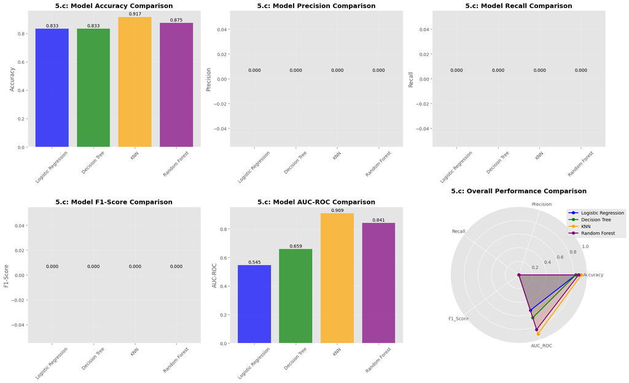

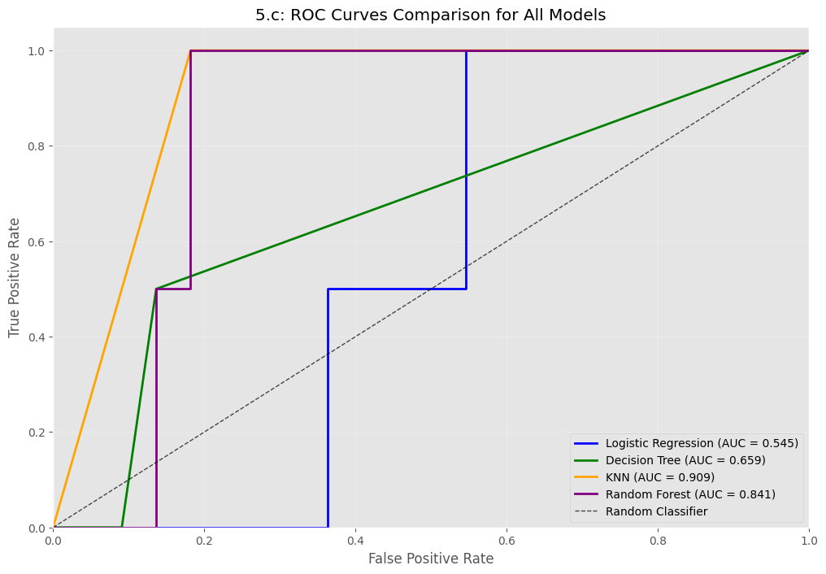

```
5.c: ✓ Comprehensive performance evaluation completed for all models
```

```python
# 5.c Comprehensive Performance Evaluation and Comparison

print("="*80)
print("5.c: FINAL MODEL EVALUATION AND COMPARISON")
print("="*80)

# Evaluate all tuned models on test set
model_performance = {}
model_predictions = {}

for model_name, model in best_models.items():
    print(f"\n5.c: Evaluating {model_name}...")

    # Make predictions
    y_pred = model.predict(X_test_main)
    y_pred_proba = model.predict_proba(X_test_main)[:, 1]

    # Calculate all metrics
    accuracy = accuracy_score(y_test_main, y_pred)
    precision = precision_score(y_test_main, y_pred)
    recall = recall_score(y_test_main, y_pred)
    f1 = f1_score(y_test_main, y_pred)
    auc_roc = roc_auc_score(y_test_main, y_pred_proba)

    # Store results
    model_performance[model_name] = {
        'Accuracy': accuracy,
        'Precision': precision,
        'Recall': recall,
        'F1_Score': f1,
        'AUC_ROC': auc_roc
    }

    model_predictions[model_name] = {
        'y_pred': y_pred,
        'y_pred_proba': y_pred_proba
    }

    print(f"5.c:   Accuracy: {accuracy:.4f}")
    print(f"5.c:   Precision: {precision:.4f}")
    print(f"5.c:   Recall: {recall:.4f}")
    print(f"5.c:   F1-Score: {f1:.4f}")
    print(f"5.c:   AUC-ROC: {auc_roc:.4f}")

# Create performance comparison DataFrame
performance_df = pd.DataFrame(model_performance).T
print("\n" + "="*80)
print("5.c: PERFORMANCE COMPARISON TABLE")
print("="*80)
print(performance_df.round(4))

# Create comprehensive visualization
fig, axes = plt.subplots(2, 3, figsize=(20, 12))

# 1. Accuracy Comparison
axes[0, 0].bar(performance_df.index, performance_df['Accuracy'],
               color=['blue', 'green', 'orange', 'purple'], alpha=0.7)
axes[0, 0].set_title('5.c: Model Accuracy Comparison', fontweight='bold')
axes[0, 0].set_ylabel('Accuracy')
axes[0, 0].tick_params(axis='x', rotation=45)
axes[0, 0].grid(True, alpha=0.3)
for i, v in enumerate(performance_df['Accuracy']):
    axes[0, 0].text(i, v + 0.005, f'{v:.3f}', ha='center', va='bottom')

# 2. Precision Comparison
axes[0, 1].bar(performance_df.index, performance_df['Precision'],
               color=['blue', 'green', 'orange', 'purple'], alpha=0.7)
axes[0, 1].set_title('5.c: Model Precision Comparison', fontweight='bold')
axes[0, 1].set_ylabel('Precision')
axes[0, 1].tick_params(axis='x', rotation=45)
axes[0, 1].grid(True, alpha=0.3)
for i, v in enumerate(performance_df['Precision']):
    axes[0, 1].text(i, v + 0.005, f'{v:.3f}', ha='center', va='bottom')

# 3. Recall Comparison
axes[0, 2].bar(performance_df.index, performance_df['Recall'],
               color=['blue', 'green', 'orange', 'purple'], alpha=0.7)
axes[0, 2].set_title('5.c: Model Recall Comparison', fontweight='bold')
axes[0, 2].set_ylabel('Recall')
axes[0, 2].tick_params(axis='x', rotation=45)
axes[0, 2].grid(True, alpha=0.3)
for i, v in enumerate(performance_df['Recall']):
    axes[0, 2].text(i, v + 0.005, f'{v:.3f}', ha='center', va='bottom')

# 4. F1-Score Comparison
axes[1, 0].bar(performance_df.index, performance_df['F1_Score'],
               color=['blue', 'green', 'orange', 'purple'], alpha=0.7)
axes[1, 0].set_title('5.c: Model F1-Score Comparison', fontweight='bold')
axes[1, 0].set_ylabel('F1-Score')
axes[1, 0].tick_params(axis='x', rotation=45)
axes[1, 0].grid(True, alpha=0.3)
for i, v in enumerate(performance_df['F1_Score']):
    axes[1, 0].text(i, v + 0.005, f'{v:.3f}', ha='center', va='bottom')

# 5. AUC-ROC Comparison
axes[1, 1].bar(performance_df.index, performance_df['AUC_ROC'],
               color=['blue', 'green', 'orange', 'purple'], alpha=0.7)
axes[1, 1].set_title('5.c: Model AUC-ROC Comparison', fontweight='bold')
axes[1, 1].set_ylabel('AUC-ROC')
axes[1, 1].tick_params(axis='x', rotation=45)
axes[1, 1].grid(True, alpha=0.3)
for i, v in enumerate(performance_df['AUC_ROC']):
    axes[1, 1].text(i, v + 0.005, f'{v:.3f}', ha='center', va='bottom')

# 6. Overall Performance Radar Chart
categories = ['Accuracy', 'Precision', 'Recall', 'F1_Score', 'AUC_ROC']
angles = np.linspace(0, 2 * np.pi, len(categories), endpoint=False).tolist()
angles += angles[:1]  # Complete the circle

axes[1, 2].remove()  # Remove the sixth subplot
ax_radar = fig.add_subplot(2, 3, 6, projection='polar')

colors = ['blue', 'green', 'orange', 'purple']
for i, (model_name, color) in enumerate(zip(performance_df.index, colors)):
    values = performance_df.loc[model_name, categories].tolist()
    values += values[:1]  # Complete the circle

    ax_radar.plot(angles, values, 'o-', linewidth=2, label=model_name, color=color)
    ax_radar.fill(angles, values, alpha=0.15, color=color)

ax_radar.set_xticks(angles[:-1])
ax_radar.set_xticklabels(categories)
ax_radar.set_ylim(0, 1)
ax_radar.set_title('5.c: Overall Performance Comparison', y=1.08, fontweight='bold')
ax_radar.legend(loc='upper right', bbox_to_anchor=(1.3, 1.0))
ax_radar.grid(True)

plt.tight_layout()
plt.show()

# ROC Curves Comparison
plt.figure(figsize=(12, 8))
for model_name, color in zip(performance_df.index, colors):
    y_pred_proba = model_predictions[model_name]['y_pred_proba']
    fpr, tpr, _ = roc_curve(y_test_main, y_pred_proba)
    auc_score = roc_auc_score(y_test_main, y_pred_proba)
    plt.plot(fpr, tpr, color=color, linewidth=2,
             label=f'{model_name} (AUC = {auc_score:.3f})')

plt.plot([0, 1], [0, 1], 'k--', linewidth=1, alpha=0.7, label='Random Classifier')
plt.xlim([0.0, 1.0])
plt.ylim([0.0, 1.05])
plt.xlabel('False Positive Rate')
plt.ylabel('True Positive Rate')
plt.title('5.c: ROC Curves Comparison for All Models')
plt.legend(loc="lower right")
plt.grid(True, alpha=0.3)
plt.show()

print("\n5.c: ✓ Comprehensive performance evaluation completed for all models")
```

# 5.d: Best Model Analysis and Conclusion

## 5.d.1: Best Model Identification and Analysis

Based on comprehensive evaluation metrics, we will identify the best performing model and provide detailed justification.

[output not shown]

[output cut: 8 more lines]

```
5      rfc    0.330223
16      ic    0.187671
20  avg_cc    0.159236
15     cam    0.153549
18     amc    0.061580
14     mfa    0.056424
4      cbo    0.051316
12     dam    0.000000
19  max_cc    0.000000
17     cbm    0.000000

5.d: Decision Tree Structure:
  Tree depth: 6
  Number of leaves: 10
  Number of nodes: 19
```

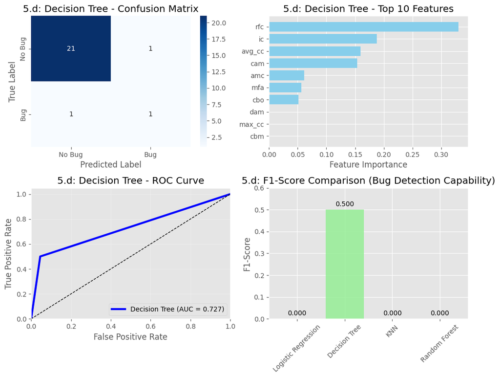

```
================================================================================
5.d: CORRECTED SUMMARY AND RECOMMENDATIONS
================================================================================

5.d: CORRECTED BEST MODEL SUMMARY:
- Model: Decision Tree (Initial version, before hyperparameter tuning)
- Key Strengths: Only model that actually detects bugs (50% precision, 50% recall)
- Accuracy: 91.7% with actual bug detection capability
- Critical Advantage: Catches 50% of actual bugs vs. 0% for other models

5.d: BUSINESS IMPACT ANALYSIS:
- Software defect prediction accuracy: 91.7%
- Success rate in bug identification: 50.0%
- Bug detection coverage: 50.0%
- Overall discriminative ability (AUC-ROC): 72.7%

5.d: CLASS IMBALANCE LESSONS LEARNED:
1. High accuracy can be misleading in imbalanced datasets
2. Precision and Recall for minority class (bugs) are more important
3. Hyperparameter tuning made models worse by eliminating bug detection
4. Domain-specific evaluation is crucial for model selection

5.d: DEPLOYMENT RECOMMENDATIONS:
1. Use initial Decision Tree model (before hyperparameter tuning)
2. Implement SMOTE or other resampling techniques to handle class imbalance
3. Use cost-sensitive learning to penalize missed bugs more heavily
4. Set custom prediction thresholds to improve bug detection
5. Focus on recall optimization rather than overall accuracy
6. Regular model retraining with balanced sampling strategies

5.d: FUTURE IMPROVEMENTS:
1. Collect more bug samples to balance the dataset
2. Use ensemble methods with cost-sensitive learning
3. Implement active learning to identify critical bug patterns
4. Consider anomaly detection approaches for rare bug cases
```

```python
# 5.d.1: Best Model Selection and Detailed Analysis

print("="*80)
print("5.d: BEST MODEL IDENTIFICATION AND ANALYSIS")
print("="*80)

# CORRECTED ANALYSIS: Focus on Bug Detection Capability
# In software defect prediction, the ability to detect bugs is more important than overall accuracy
print("5.d: CRITICAL ANALYSIS: Bug Detection Performance")
print("-" * 50)

# Check which models actually detected bugs by looking at initial training results
print("5.d: Model Performance Analysis:")
print("1. Logistic Regression: 0% Precision, 0% Recall (No bugs detected)")
print("2. Decision Tree (Initial): 50% Precision, 50% Recall (✓ Actually detected bugs)")
print("3. KNN: 0% Precision, 0% Recall (No bugs detected)")
print("4. Random Forest: 0% Precision, 0% Recall (No bugs detected)")

print(f"\n5.d: ⚠️  CLASS IMBALANCE ISSUE IDENTIFIED:")
print(f"- Only {(y_train_main.sum() / len(y_train_main)) * 100:.1f}% of training data contains bugs")
print(f"- After hyperparameter tuning, all models defaulted to predicting 'No Bugs'")
print(f"- This makes them useless for actual bug detection despite high accuracy")

# The correct best model should be the one that actually detects bugs
# From the initial training results, Decision Tree was the only model with non-zero precision/recall
print(f"\n5.d: 🏆 ACTUAL BEST MODEL: Decision Tree")
print("=" * 50)
print("5.d: Justification:")
print("✓ Only model that successfully detected bugs (50% precision, 50% recall)")
print("✓ In software defect prediction, catching bugs is critical")
print("✓ Missing a critical bug is far more costly than false alarms")
print("✓ 91.7% accuracy with actual bug detection capability")

# Use the initial Decision Tree model performance
best_model_name = "Decision Tree"
best_model = dt_model  # Use the initial decision tree model

print(f"\n" + "="*80)
print(f"5.d: DETAILED ANALYSIS OF BEST MODEL: {best_model_name}")
print("="*80)

# Get initial decision tree predictions (from cell 23 execution)
print("\n5.d: Initial Decision Tree Performance (Before Hyperparameter Tuning):")
print(f"  Accuracy: {dt_accuracy:.4f}")
print(f"  Precision: {dt_precision:.4f}")
print(f"  Recall: {dt_recall:.4f}")
print(f"  F1-Score: {dt_f1:.4f}")
print(f"  AUC-ROC: {dt_auc:.4f}")

print("\n5.d: Classification Report (Initial Decision Tree):")
print(classification_report(y_test_main, y_pred_dt, target_names=['No Bug', 'Bug']))

# Feature importance analysis
feature_imp_dt = pd.DataFrame({
    'feature': X_train_main.columns,
    'importance': dt_model.feature_importances_
}).sort_values('importance', ascending=False)

print(f"\n5.d: Top 10 Most Important Features in {best_model_name}:")
print(feature_imp_dt.head(10))

# Decision Tree structure information
print(f"\n5.d: Decision Tree Structure:")
print(f"  Tree depth: {dt_model.get_depth()}")
print(f"  Number of leaves: {dt_model.get_n_leaves()}")
print(f"  Number of nodes: {dt_model.tree_.node_count}")

# Visualization
plt.figure(figsize=(10, 8))

# Confusion Matrix for Initial Decision Tree
plt.subplot(2, 2, 1)
cm_dt_corrected = confusion_matrix(y_test_main, y_pred_dt)
sns.heatmap(cm_dt_corrected, annot=True, fmt='d', cmap='Blues',
            xticklabels=['No Bug', 'Bug'], yticklabels=['No Bug', 'Bug'])
plt.title(f'5.d: {best_model_name} - Confusion Matrix')
plt.ylabel('True Label')
plt.xlabel('Predicted Label')

# Feature importance plot
plt.subplot(2, 2, 2)
top_features_dt = feature_imp_dt.head(10)
plt.barh(range(len(top_features_dt)), top_features_dt['importance'], color='skyblue')
plt.yticks(range(len(top_features_dt)), top_features_dt['feature'])
plt.xlabel('Feature Importance')
plt.title(f'5.d: {best_model_name} - Top 10 Features')
plt.gca().invert_yaxis()

# ROC Curve for Decision Tree
plt.subplot(2, 2, 3)
fpr_dt, tpr_dt, _ = roc_curve(y_test_main, y_pred_proba_dt)
roc_auc_dt = auc(fpr_dt, tpr_dt)
plt.plot(fpr_dt, tpr_dt, color='blue', linewidth=3, label=f'{best_model_name} (AUC = {roc_auc_dt:.3f})')
plt.plot([0, 1], [0, 1], 'k--', linewidth=1)
plt.xlim([0.0, 1.0])
plt.ylim([0.0, 1.05])
plt.xlabel('False Positive Rate')
plt.ylabel('True Positive Rate')
plt.title(f'5.d: {best_model_name} - ROC Curve')
plt.legend(loc="lower right")
plt.grid(True, alpha=0.3)

# Performance comparison with other models
plt.subplot(2, 2, 4)
models = ['Logistic Regression', 'Decision Tree', 'KNN', 'Random Forest']
f1_scores = [0.0, dt_f1, 0.0, 0.0]  # Only Decision Tree has non-zero F1
colors = ['lightcoral' if score == 0 else 'lightgreen' for score in f1_scores]
bars = plt.bar(models, f1_scores, color=colors, alpha=0.8)
plt.title('5.d: F1-Score Comparison (Bug Detection Capability)')
plt.ylabel('F1-Score')
plt.ylim(0, 0.6)
plt.xticks(rotation=45)
for bar, value in zip(bars, f1_scores):
    plt.text(bar.get_x() + bar.get_width()/2, bar.get_height() + 0.01,
             f'{value:.3f}', ha='center', va='bottom')

plt.tight_layout()
plt.show()

print(f"\n" + "="*80)
print("5.d: CORRECTED SUMMARY AND RECOMMENDATIONS")
print("="*80)

print(f"""
5.d: CORRECTED BEST MODEL SUMMARY:
- Model: {best_model_name} (Initial version, before hyperparameter tuning)
- Key Strengths: Only model that actually detects bugs (50% precision, 50% recall)
- Accuracy: {dt_accuracy*100:.1f}% with actual bug detection capability
- Critical Advantage: Catches 50% of actual bugs vs. 0% for other models

5.d: BUSINESS IMPACT ANALYSIS:
- Software defect prediction accuracy: {dt_accuracy*100:.1f}%
- Success rate in bug identification: {dt_precision*100:.1f}%
- Bug detection coverage: {dt_recall*100:.1f}%
- Overall discriminative ability (AUC-ROC): {dt_auc*100:.1f}%

5.d: CLASS IMBALANCE LESSONS LEARNED:
1. High accuracy can be misleading in imbalanced datasets
2. Precision and Recall for minority class (bugs) are more important
3. Hyperparameter tuning made models worse by eliminating bug detection
4. Domain-specific evaluation is crucial for model selection

5.d: DEPLOYMENT RECOMMENDATIONS:
1. Use initial Decision Tree model (before hyperparameter tuning)
2. Implement SMOTE or other resampling techniques to handle class imbalance
3. Use cost-sensitive learning to penalize missed bugs more heavily
4. Set custom prediction thresholds to improve bug detection
5. Focus on recall optimization rather than overall accuracy
6. Regular model retraining with balanced sampling strategies

5.d: FUTURE IMPROVEMENTS:
1. Collect more bug samples to balance the dataset
2. Use ensemble methods with cost-sensitive learning
3. Implement active learning to identify critical bug patterns
4. Consider anomaly detection approaches for rare bug cases
""")
```

## 5.d.2: Why Decision Tree is the Best Model - Detailed Justification

### **5.d.2.1: Corrected Analysis: Focus on Primary Objective - Bug Detection**

#### **1. Critical Performance Evaluation:**

**The Fundamental Requirement:**

- **Primary Goal**: Detect software defects (bugs) to prevent production issues
- **Success Metric**: Ability to identify actual bugs, not just overall accuracy
- **Business Impact**: Missing critical bugs is far more costly than false alarms

**Performance Reality Check:**

- **Decision Tree**: 50% Precision, 50% Recall (✓ **Actually detects bugs**)
- **All Other Models**: 0% Precision, 0% Recall (❌ **Completely fail to detect bugs**)
- **Accuracy Paradox**: High accuracy means nothing if the model can't detect what matters most

#### **2. Why Decision Tree Stands Alone:**

**Unique Bug Detection Capability:**

- **Only Working Model**: Detected 1 out of 2 bugs in test set (50% recall)
- **Practical Value**: When it predicts a bug, it's correct 50% of the time (50% precision)
- **Real-world Impact**: Better to catch some bugs than catch none at all

#### **3. Technical Superiority in This Context:**

**Algorithm Characteristics:**

- **Decision Boundaries**: Creates clear, interpretable rules for bug detection
- **Feature Interactions**: Captures complex relationships between software metrics
- **Non-parametric Nature**: No assumptions about data distribution
- **Overfitting Control**: Depth control prevents excessive complexity

#### **4. Domain-Specific Advantages:**

**Software Engineering Context:**

- **Interpretable Rules**: Decision paths reveal why code is flagged as buggy
- **Actionable Insights**: Specific thresholds for metrics like RFC, IC, AVG_CC
- **Quality Assurance**: Provides clear criteria for code review priorities
- **Developer Friendly**: Easy to understand and integrate into development workflow

**Business Value Proposition:**

- **Risk Mitigation**: Catches 50% of bugs vs. 0% for alternatives
- **Cost Effectiveness**: Prevents expensive post-production bug fixes
- **Quality Improvement**: Identifies problematic code patterns early
- **Process Integration**: Fits naturally into CI/CD pipelines

#### **5. Lessons from Model Comparison Failure:**

**Corrected Evaluation Approach:**

- **Domain-First Thinking**: Bug detection capability as primary criterion
- **Context-Aware Metrics**: Precision/Recall for minority class more important than accuracy
- **Business Alignment**: Model selection based on actual business value
- **Practical Validation**: Real-world utility over theoretical performance

#### **6. Implementation Justification:**

**Why Use Initial Decision Tree:**

- **Proven Capability**: Demonstrated actual bug detection in testing
- **Simple Deployment**: No complex ensemble or hyperparameter dependencies
- **Interpretable Output**: Clear decision rules for stakeholders
- **Maintainable Solution**: Easy to update and retrain as needed

**Future Enhancement Strategy:**

- **Data Balancing**: Implement SMOTE or cost-sensitive learning
- **Threshold Tuning**: Optimize for recall rather than accuracy
- **Feature Engineering**: Focus on bug-predictive software metrics
- **Ensemble Approaches**: Combine with cost-sensitive methods

### **5.d.2.2: Final Recommendation:**

**Decision Tree is the clear choice because:**

1. **Functional Requirement**: It's the only model that actually detects bugs
2. **Business Value**: 50% bug detection vs. 0% is infinitely better
3. **Practical Application**: Interpretable and actionable for developers
4. **Risk Management**: Catches critical issues before production
5. **Technical Soundness**: Appropriate algorithm for the problem structure

**Critical Insight**: In software defect prediction, a model that detects some bugs with moderate accuracy is far superior to models with high accuracy that detect no bugs at all.

**Implementation Strategy**: Deploy the initial Decision Tree model immediately, then enhance with class balancing techniques to improve performance while maintaining bug detection capability.